# Music Recommendation System For Meditation & Relaxation

## Understanding the Dataset

### Dataset Overview

The dataset contains information related to Spotify tracks used for building a music recommendation system tailored for meditation and relaxation purposes. It includes a comprehensive set of attributes that describe various aspects of each track.

### Dataset Columns

1. **user_id**: Unique identifier for Spotify users.
2. **Track Name**: Name of the track.
3. **Artist Name(s)**: Name of the artist(s) associated with the track.
4. **Album Name**: Name of the album to which the track belongs.
5. **Album Release Date**: Release date of the album.
6. **Track Number**: Unique track number within the album.
7. **Track Duration (ms)**: Duration of the track in milliseconds.
8. **Explicit**: Indicator if the track contains explicit content.
9. **Popularity**: Measure indicating how popular a track is based on its play count.
10. **Added By**: User who added the track to a playlist.
11. **Added At**: Timestamp when the track was added to the playlist.
12. **Danceability**: Metric describing how suitable a track is for dancing based on tempo, rhythm stability, beat strength, and overall regularity.
13. **Energy**: Perceptual measure of intensity and activity in the track.
14. **Key**: The key in which the track is performed. Integers map to pitches using standard Pitch Class notation.
15. **Loudness**: Loudness of the track in decibels (dB).
16. **Mode**: Indicates the modality (major or minor) of the track.
17. **Speechiness**: Presence of spoken words in the track, measured as the ratio of speech-like sounds to music-like sounds.
18. **Acousticness**: Confidence measure from 0.0 to 1.0 indicating whether the track is acoustic.
19. **Instrumentalness**: Predicts whether a track contains vocals. Higher values suggest instrumental tracks.
20. **Liveness**: Detects the presence of an audience in the recording. Higher values represent higher probability of a live audience.
21. **Valence**: Measure from 0.0 to 1.0 describing the musical positiveness conveyed by a track.
22. **Tempo**: Beats per minute (BPM) of the track.
23. **Time Signature**: Estimated overall time signature of the track.

### Usage Context

This dataset is pivotal for developing a music recommendation system that caters specifically to meditation and relaxation needs. By analyzing attributes such as acousticness, instrumentalness, and valence, the system aims to recommend tracks that align with calming and soothing musical preferences.

### Spotify Dataset

[figure not shown]

```python
from PIL import Image
Spotify_data = Image.open("C://Users//dell//Downloads//Screenshot (1).png");
Spotify_data
```

```python
import pandas as pd
import numpy as np
```

```python
#importing and merging two csv files
df = pd.concat(
    map(pd.read_csv,['meditationandrelaxation1.csv', 'meditationandrelaxation2.csv', 'meditationandrelaxation3.csv', 'meditationandrelaxation4.csv', 'meditationandrelaxation5.csv']), ignore_index=True)
print(df)
```

```
                                   Track URI                   Track Name  \
0       spotify:track:4wDkM4eonFlMpw07mQxZbM            Meditation Awaken
1       spotify:track:0dLkW1wbEi6nzyLQOwNCMv                 Yoga Top 100
2     spotify:episode:6tpsPNJECk1eLbsPJgXNBR  Meditation - Naval Ravikant
3       spotify:track:1oVgCauMXygkALiOtI51M1                 Yoga Top 100
4     spotify:episode:5fLpnfOalU991SfSu9r7z8       Meditation - by A Monk
...                                      ...                          ...
1282    spotify:track:52bpdusCUIPfzrRZ8n4FRP                       Maitri
1283    spotify:track:71kayL70PNWQIHWt5P8uhU            Spiritual Teacher
1284    spotify:track:77PyhSbcu8ctjPbVGSwaa9                       Chakra
1285    spotify:track:3vmjzmOGGlPczWQWNf7cE0                       Elixir
1286    spotify:track:5AJIr4CC0Te4HOofAtmYa8                    Kundalini

                                          Artist URI(s)  \
0                 spotify:artist:568O2cGvLWBRq81ESU0Dlw
```

[output cut: 116 more lines]

```python
df.head()
```

|  | Track URI | Track Name | Artist URI(s) | Artist Name(s) | Album URI | Album Name | Album Artist URI(s) | Album Artist Name(s) | Album Release Date | Album Image URL | ... | Key | Loudness | Mode | Speechiness | Acousticness | Instrumentalness | Liveness | Valence | Tempo | Time Signature |
| --- | --- | --- | --- | --- | --- | --- | --- | --- | --- | --- | --- | --- | --- | --- | --- | --- | --- | --- | --- | --- | --- |
| 0 | spotify:track:4wDkM4eonFlMpw07mQxZbM | Meditation Awaken | spotify:artist:568O2cGvLWBRq81ESU0Dlw | Chakra Healing Music Academy | spotify:album:5iVlr7HTEOSDECK1ImyUoR | Genius Brain Frequency: Top 100 Chakra Healing... | spotify:artist:568O2cGvLWBRq81ESU0Dlw | Chakra Healing Music Academy | 2022-01-04 | https://i.scdn.co/image/ab67616d0000b273b7a6a6... | ... | 0.0 | -23.311 | 1.0 | 0.0366 | 0.986 | 0.872 | 0.0884 | 0.0368 | 75.166 | 4.0 |
| 1 | spotify:track:0dLkW1wbEi6nzyLQOwNCMv | Yoga Top 100 | spotify:artist:3uilhWYZIH4z0KQRoywFC8, spotify... | Yoga Training Music Ensemble, Healing Yoga Med... | spotify:album:2BG3DdCdDNpVOKVjnSZSs8 | Anxiety Meditation and Yoga for Insecurity: Re... | spotify:artist:3uilhWYZIH4z0KQRoywFC8, spotify... | Yoga Training Music Ensemble, Healing Yoga Med... | 2021-09-07 | https://i.scdn.co/image/ab67616d0000b273f68cbf... | ... | 5.0 | -22.049 | 1.0 | 0.0499 | 0.922 | 0.917 | 0.1010 | 0.0372 | 88.407 | 4.0 |
| 2 | spotify:episode:6tpsPNJECk1eLbsPJgXNBR | Meditation - Naval Ravikant | spotify:show:7IG2XdnbjH3eTubEopFAuB | Self Improvement through Top 100 Books | spotify:show:7IG2XdnbjH3eTubEopFAuB | Self Improvement through Top 100 Books | spotify:show:7IG2XdnbjH3eTubEopFAuB | Self Improvement through Top 100 Books | NaN | https://i.scdn.co/image/ab6765630000ba8a087cce... | ... | NaN | NaN | NaN | NaN | NaN | NaN | NaN | NaN | NaN | NaN |
| 3 | spotify:track:1oVgCauMXygkALiOtI51M1 | Yoga Top 100 | spotify:artist:30u03dHVwT6ByMPQYs7e2P | Namaste Healing Yoga | spotify:album:4zH8WhBULRyaEtZOivWESO | Zen Meditation Music 111: Relaxing Flute Piano... | spotify:artist:0LyfQWJT6nXafLPZqxe9Of | Various Artists | 2016-05-23 | https://i.scdn.co/image/ab67616d0000b273f5a637... | ... | 10.0 | -24.113 | 1.0 | 0.0421 | 0.843 | 0.947 | 0.1300 | 0.0534 | 102.475 | 3.0 |
| 4 | spotify:episode:5fLpnfOalU991SfSu9r7z8 | Meditation - by A Monk | spotify:show:7IG2XdnbjH3eTubEopFAuB | Self Improvement through Top 100 Books | spotify:show:7IG2XdnbjH3eTubEopFAuB | Self Improvement through Top 100 Books | spotify:show:7IG2XdnbjH3eTubEopFAuB | Self Improvement through Top 100 Books | NaN | https://i.scdn.co/image/ab6765630000ba8a087cce... | ... | NaN | NaN | NaN | NaN | NaN | NaN | NaN | NaN | NaN | NaN |

5 rows × 30 columns

## EDA (Exploratory Data Analysis)

```python
#finding total NaN values in dataset
df.isna().sum()
```

```
Track URI                 0
Track Name                0
Artist URI(s)             0
Artist Name(s)            0
Album URI                 0
Album Name                0
Album Artist URI(s)       0
Album Artist Name(s)      0
Album Release Date       95
Album Image URL           0
Disc Number               0
Track Number              0
Track Duration (ms)       0
Track Preview URL         1
Explicit                  0
Popularity                0
Added By                  0
Added At                  0
Danceability            155
Energy                  155
Key                     155
Loudness                155
Mode                    155
Speechiness             155
Acousticness            155
Instrumentalness        155
Liveness                155
Valence                 155
Tempo                   155
Time Signature          155
dtype: int64
```

```python
#displaying all rows having all NaN values
df[df.isnull().any(axis=1)]
```

|  | Track URI | Track Name | Artist URI(s) | Artist Name(s) | Album URI | Album Name | Album Artist URI(s) | Album Artist Name(s) | Album Release Date | Album Image URL | ... | Key | Loudness | Mode | Speechiness | Acousticness | Instrumentalness | Liveness | Valence | Tempo | Time Signature |
| --- | --- | --- | --- | --- | --- | --- | --- | --- | --- | --- | --- | --- | --- | --- | --- | --- | --- | --- | --- | --- | --- |
| 2 | spotify:episode:6tpsPNJECk1eLbsPJgXNBR | Meditation - Naval Ravikant | spotify:show:7IG2XdnbjH3eTubEopFAuB | Self Improvement through Top 100 Books | spotify:show:7IG2XdnbjH3eTubEopFAuB | Self Improvement through Top 100 Books | spotify:show:7IG2XdnbjH3eTubEopFAuB | Self Improvement through Top 100 Books | NaN | https://i.scdn.co/image/ab6765630000ba8a087cce... | ... | NaN | NaN | NaN | NaN | NaN | NaN | NaN | NaN | NaN | NaN |
| 4 | spotify:episode:5fLpnfOalU991SfSu9r7z8 | Meditation - by A Monk | spotify:show:7IG2XdnbjH3eTubEopFAuB | Self Improvement through Top 100 Books | spotify:show:7IG2XdnbjH3eTubEopFAuB | Self Improvement through Top 100 Books | spotify:show:7IG2XdnbjH3eTubEopFAuB | Self Improvement through Top 100 Books | NaN | https://i.scdn.co/image/ab6765630000ba8a087cce... | ... | NaN | NaN | NaN | NaN | NaN | NaN | NaN | NaN | NaN | NaN |
| 5 | spotify:episode:6tpsPNJECk1eLbsPJgXNBR | Meditation - Naval Ravikant | spotify:show:7IG2XdnbjH3eTubEopFAuB | Self Improvement through Top 100 Books | spotify:show:7IG2XdnbjH3eTubEopFAuB | Self Improvement through Top 100 Books | spotify:show:7IG2XdnbjH3eTubEopFAuB | Self Improvement through Top 100 Books | NaN | https://i.scdn.co/image/ab6765630000ba8a087cce... | ... | NaN | NaN | NaN | NaN | NaN | NaN | NaN | NaN | NaN | NaN |
| 109 | spotify:episode:5Krsp55kY3goGGqkBV26ej | 15 Minute Super Deep Meditation Music: Relax M... | spotify:show:1dKiVyh2JEe4KrPKrvm3aB | Mediation | spotify:show:1dKiVyh2JEe4KrPKrvm3aB | Mediation | spotify:show:1dKiVyh2JEe4KrPKrvm3aB | Mediation | NaN | https://i.scdn.co/image/698b78f04cca0c2af50e23... | ... | NaN | NaN | NaN | NaN | NaN | NaN | NaN | NaN | NaN | NaN |
| 174 | spotify:episode:3oVSxuDiphnEI9WrvFVdqo | Healing Sounds: Cleans the Aura and Space. Rem... | spotify:show:4O9ewm6rHndbj2AiagZiUG | MEDITATION SELF | spotify:show:4O9ewm6rHndbj2AiagZiUG | MEDITATION SELF | spotify:show:4O9ewm6rHndbj2AiagZiUG | MEDITATION SELF | NaN | https://i.scdn.co/image/4514ca814660f983cdb29e... | ... | NaN | NaN | NaN | NaN | NaN | NaN | NaN | NaN | NaN | NaN |
| ... | ... | ... | ... | ... | ... | ... | ... | ... | ... | ... | ... | ... | ... | ... | ... | ... | ... | ... | ... | ... | ... |
| 1151 | spotify:episode:3oVSxuDiphnEI9WrvFVdqo | Healing Sounds: Cleans the Aura and Space. Rem... | spotify:show:4O9ewm6rHndbj2AiagZiUG | MEDITATION SELF | spotify:show:4O9ewm6rHndbj2AiagZiUG | MEDITATION SELF | spotify:show:4O9ewm6rHndbj2AiagZiUG | MEDITATION SELF | NaN | https://i.scdn.co/image/4514ca814660f983cdb29e... | ... | NaN | NaN | NaN | NaN | NaN | NaN | NaN | NaN | NaN | NaN |
| 1152 | spotify:episode:3oVSxuDiphnEI9WrvFVdqo | Healing Sounds: Cleans the Aura and Space. Rem... | spotify:show:4O9ewm6rHndbj2AiagZiUG | MEDITATION SELF | spotify:show:4O9ewm6rHndbj2AiagZiUG | MEDITATION SELF | spotify:show:4O9ewm6rHndbj2AiagZiUG | MEDITATION SELF | NaN | https://i.scdn.co/image/4514ca814660f983cdb29e... | ... | NaN | NaN | NaN | NaN | NaN | NaN | NaN | NaN | NaN | NaN |
| 1153 | spotify:episode:3oVSxuDiphnEI9WrvFVdqo | Healing Sounds: Cleans the Aura and Space. Rem... | spotify:show:4O9ewm6rHndbj2AiagZiUG | MEDITATION SELF | spotify:show:4O9ewm6rHndbj2AiagZiUG | MEDITATION SELF | spotify:show:4O9ewm6rHndbj2AiagZiUG | MEDITATION SELF | NaN | https://i.scdn.co/image/4514ca814660f983cdb29e... | ... | NaN | NaN | NaN | NaN | NaN | NaN | NaN | NaN | NaN | NaN |
| 1155 | spotify:episode:35YCJuheZCJD5HsnkaS3P7 | [Study Sleep Relax 💖] Meditation - music | spotify:show:64ijNYNNSIzrNFEcXwB6YL | Relaxing music | spotify:show:64ijNYNNSIzrNFEcXwB6YL | Relaxing music | spotify:show:64ijNYNNSIzrNFEcXwB6YL | Relaxing music | NaN | https://i.scdn.co/image/ab6765630000ba8aeed951... | ... | NaN | NaN | NaN | NaN | NaN | NaN | NaN | NaN | NaN | NaN |
| 1156 | spotify:episode:07HQ80zuAB7D0KgDNPlMFz | Relaxing Sleep Music • Deep Sleeping Music, Re... | spotify:show:1WTKOss6rssszbgoVh0QN0 | Comforting Sounds | spotify:show:1WTKOss6rssszbgoVh0QN0 | Comforting Sounds | spotify:show:1WTKOss6rssszbgoVh0QN0 | Comforting Sounds | NaN | https://i.scdn.co/image/ab6765630000ba8ab1883f... | ... | NaN | NaN | NaN | NaN | NaN | NaN | NaN | NaN | NaN | NaN |

156 rows × 30 columns

```python
#coverting dtype of object to datetime
df['Album Release Date'] = pd.to_datetime(df['Album Release Date'])
df.dtypes
```

```
Track URI                       object
Track Name                      object
Artist URI(s)                   object
Artist Name(s)                  object
Album URI                       object
Album Name                      object
Album Artist URI(s)             object
Album Artist Name(s)            object
Album Release Date      datetime64[ns]
Album Image URL                 object
Disc Number                      int64
Track Number                     int64
Track Duration (ms)              int64
Track Preview URL               object
Explicit                          bool
Popularity                       int64
Added By                        object
Added At                        object
Danceability                   float64
Energy                         float64
Key                            float64
Loudness                       float64
Mode                           float64
Speechiness                    float64
Acousticness                   float64
Instrumentalness               float64
Liveness                       float64
Valence                        float64
Tempo                          float64
Time Signature                 float64
dtype: object
```

```python
df.shape
```

```
(1287, 30)
```

```python
df.describe()
```

|  | Disc Number | Track Number | Track Duration (ms) | Popularity | Danceability | Energy | Key | Loudness | Mode | Speechiness | Acousticness | Instrumentalness | Liveness | Valence | Tempo | Time Signature |
| --- | --- | --- | --- | --- | --- | --- | --- | --- | --- | --- | --- | --- | --- | --- | --- | --- |
| count | 1287.000000 | 1287.000000 | 1.287000e+03 | 1287.000000 | 1132.000000 | 1132.000000 | 1132.000000 | 1132.000000 | 1132.000000 | 1132.000000 | 1132.000000 | 1132.000000 | 1132.000000 | 1132.000000 | 1132.000000 | 1132.000000 |
| mean | 0.926185 | 15.230769 | 5.855823e+05 | 12.702409 | 0.232496 | 0.176255 | 4.766784 | -25.155986 | 0.675795 | 0.061512 | 0.831158 | 0.798753 | 0.185348 | 0.093422 | 96.196466 | 3.645760 |
| std | 0.261571 | 15.529144 | 1.613435e+06 | 14.743136 | 0.137524 | 0.214033 | 3.544642 | 6.867583 | 0.468284 | 0.075965 | 0.250707 | 0.267468 | 0.186740 | 0.115242 | 30.279224 | 0.903353 |
| min | 0.000000 | 0.000000 | 3.100000e+04 | 0.000000 | 0.000000 | 0.000059 | 0.000000 | -47.004000 | 0.000000 | 0.000000 | 0.000000 | 0.000000 | 0.044400 | 0.000000 | 0.000000 | 0.000000 |
| 25% | 1.000000 | 4.000000 | 1.358560e+05 | 0.000000 | 0.149000 | 0.040325 | 2.000000 | -29.018250 | 0.000000 | 0.039200 | 0.804750 | 0.806000 | 0.098300 | 0.035500 | 74.071000 | 3.000000 |
| 50% | 1.000000 | 11.000000 | 2.124120e+05 | 4.000000 | 0.190000 | 0.108000 | 4.000000 | -24.751500 | 1.000000 | 0.044500 | 0.937000 | 0.908000 | 0.111000 | 0.039800 | 87.654500 | 4.000000 |
| 75% | 1.000000 | 23.000000 | 2.580705e+05 | 25.000000 | 0.271000 | 0.209000 | 8.000000 | -20.209500 | 1.000000 | 0.053200 | 0.980000 | 0.953000 | 0.150000 | 0.109000 | 115.969750 | 4.000000 |
| max | 1.000000 | 284.000000 | 1.277986e+07 | 59.000000 | 0.808000 | 1.000000 | 11.000000 | -6.989000 | 1.000000 | 0.937000 | 0.996000 | 1.000000 | 0.976000 | 0.907000 | 186.565000 | 5.000000 |

```python
#displaying column name
df.columns
```

```
Index(['Track URI', 'Track Name', 'Artist URI(s)', 'Artist Name(s)',
       'Album URI', 'Album Name', 'Album Artist URI(s)',
       'Album Artist Name(s)', 'Album Release Date', 'Album Image URL',
       'Disc Number', 'Track Number', 'Track Duration (ms)',
       'Track Preview URL', 'Explicit', 'Popularity', 'Added By', 'Added At',
       'Danceability', 'Energy', 'Key', 'Loudness', 'Mode', 'Speechiness',
       'Acousticness', 'Instrumentalness', 'Liveness', 'Valence', 'Tempo',
       'Time Signature'],
      dtype='object')
```

```python
df.dtypes
```

```
Track URI                       object
Track Name                      object
Artist URI(s)                   object
Artist Name(s)                  object
Album URI                       object
Album Name                      object
Album Artist URI(s)             object
Album Artist Name(s)            object
Album Release Date      datetime64[ns]
Album Image URL                 object
Disc Number                      int64
Track Number                     int64
Track Duration (ms)              int64
Track Preview URL               object
Explicit                          bool
Popularity                       int64
Added By                        object
Added At                        object
Danceability                   float64
Energy                         float64
Key                            float64
Loudness                       float64
Mode                           float64
Speechiness                    float64
Acousticness                   float64
Instrumentalness               float64
Liveness                       float64
Valence                        float64
Tempo                          float64
Time Signature                 float64
dtype: object
```

```python
#creating random user names
nodes=['{0}'.format(i) for i in range(1,151)]
```

```python
print(nodes)
```

[output not shown]

```python
import numpy as np
```

```python
#inserting random user name
df["user"] = np.random.choice(nodes, size=len(df))
```

```python
df.dtypes
```

```
Track URI                       object
Track Name                      object
Artist URI(s)                   object
Artist Name(s)                  object
Album URI                       object
Album Name                      object
Album Artist URI(s)             object
Album Artist Name(s)            object
Album Release Date      datetime64[ns]
Album Image URL                 object
Disc Number                      int64
Track Number                     int64
Track Duration (ms)              int64
Track Preview URL               object
Explicit                          bool
Popularity                       int64
Added By                        object
Added At                        object
Danceability                   float64
Energy                         float64
Key                            float64
Loudness                       float64
Mode                           float64
Speechiness                    float64
Acousticness                   float64
Instrumentalness               float64
Liveness                       float64
Valence                        float64
Tempo                          float64
Time Signature                 float64
user                            object
dtype: object
```

```python
df.head()
```

|  | Track URI | Track Name | Artist URI(s) | Artist Name(s) | Album URI | Album Name | Album Artist URI(s) | Album Artist Name(s) | Album Release Date | Album Image URL | ... | Loudness | Mode | Speechiness | Acousticness | Instrumentalness | Liveness | Valence | Tempo | Time Signature | user |
| --- | --- | --- | --- | --- | --- | --- | --- | --- | --- | --- | --- | --- | --- | --- | --- | --- | --- | --- | --- | --- | --- |
| 0 | spotify:track:4wDkM4eonFlMpw07mQxZbM | Meditation Awaken | spotify:artist:568O2cGvLWBRq81ESU0Dlw | Chakra Healing Music Academy | spotify:album:5iVlr7HTEOSDECK1ImyUoR | Genius Brain Frequency: Top 100 Chakra Healing... | spotify:artist:568O2cGvLWBRq81ESU0Dlw | Chakra Healing Music Academy | 2022-01-04 | https://i.scdn.co/image/ab67616d0000b273b7a6a6... | ... | -23.311 | 1.0 | 0.0366 | 0.986 | 0.872 | 0.0884 | 0.0368 | 75.166 | 4.0 | 41 |
| 1 | spotify:track:0dLkW1wbEi6nzyLQOwNCMv | Yoga Top 100 | spotify:artist:3uilhWYZIH4z0KQRoywFC8, spotify... | Yoga Training Music Ensemble, Healing Yoga Med... | spotify:album:2BG3DdCdDNpVOKVjnSZSs8 | Anxiety Meditation and Yoga for Insecurity: Re... | spotify:artist:3uilhWYZIH4z0KQRoywFC8, spotify... | Yoga Training Music Ensemble, Healing Yoga Med... | 2021-09-07 | https://i.scdn.co/image/ab67616d0000b273f68cbf... | ... | -22.049 | 1.0 | 0.0499 | 0.922 | 0.917 | 0.1010 | 0.0372 | 88.407 | 4.0 | 29 |
| 2 | spotify:episode:6tpsPNJECk1eLbsPJgXNBR | Meditation - Naval Ravikant | spotify:show:7IG2XdnbjH3eTubEopFAuB | Self Improvement through Top 100 Books | spotify:show:7IG2XdnbjH3eTubEopFAuB | Self Improvement through Top 100 Books | spotify:show:7IG2XdnbjH3eTubEopFAuB | Self Improvement through Top 100 Books | NaT | https://i.scdn.co/image/ab6765630000ba8a087cce... | ... | NaN | NaN | NaN | NaN | NaN | NaN | NaN | NaN | NaN | 102 |
| 3 | spotify:track:1oVgCauMXygkALiOtI51M1 | Yoga Top 100 | spotify:artist:30u03dHVwT6ByMPQYs7e2P | Namaste Healing Yoga | spotify:album:4zH8WhBULRyaEtZOivWESO | Zen Meditation Music 111: Relaxing Flute Piano... | spotify:artist:0LyfQWJT6nXafLPZqxe9Of | Various Artists | 2016-05-23 | https://i.scdn.co/image/ab67616d0000b273f5a637... | ... | -24.113 | 1.0 | 0.0421 | 0.843 | 0.947 | 0.1300 | 0.0534 | 102.475 | 3.0 | 150 |
| 4 | spotify:episode:5fLpnfOalU991SfSu9r7z8 | Meditation - by A Monk | spotify:show:7IG2XdnbjH3eTubEopFAuB | Self Improvement through Top 100 Books | spotify:show:7IG2XdnbjH3eTubEopFAuB | Self Improvement through Top 100 Books | spotify:show:7IG2XdnbjH3eTubEopFAuB | Self Improvement through Top 100 Books | NaT | https://i.scdn.co/image/ab6765630000ba8a087cce... | ... | NaN | NaN | NaN | NaN | NaN | NaN | NaN | NaN | NaN | 8 |

5 rows × 31 columns

```python
df.user
```

```
0        41
1        29
2       102
3       150
4         8
       ...
1282    136
1283    133
1284     45
1285     64
1286     36
Name: user, Length: 1287, dtype: object
```

```python
df
```

|  | Track URI | Track Name | Artist URI(s) | Artist Name(s) | Album URI | Album Name | Album Artist URI(s) | Album Artist Name(s) | Album Release Date | Album Image URL | ... | Loudness | Mode | Speechiness | Acousticness | Instrumentalness | Liveness | Valence | Tempo | Time Signature | user |
| --- | --- | --- | --- | --- | --- | --- | --- | --- | --- | --- | --- | --- | --- | --- | --- | --- | --- | --- | --- | --- | --- |
| 0 | spotify:track:4wDkM4eonFlMpw07mQxZbM | Meditation Awaken | spotify:artist:568O2cGvLWBRq81ESU0Dlw | Chakra Healing Music Academy | spotify:album:5iVlr7HTEOSDECK1ImyUoR | Genius Brain Frequency: Top 100 Chakra Healing... | spotify:artist:568O2cGvLWBRq81ESU0Dlw | Chakra Healing Music Academy | 2022-01-04 | https://i.scdn.co/image/ab67616d0000b273b7a6a6... | ... | -23.311 | 1.0 | 0.0366 | 0.986 | 0.872 | 0.0884 | 0.0368 | 75.166 | 4.0 | 41 |
| 1 | spotify:track:0dLkW1wbEi6nzyLQOwNCMv | Yoga Top 100 | spotify:artist:3uilhWYZIH4z0KQRoywFC8, spotify... | Yoga Training Music Ensemble, Healing Yoga Med... | spotify:album:2BG3DdCdDNpVOKVjnSZSs8 | Anxiety Meditation and Yoga for Insecurity: Re... | spotify:artist:3uilhWYZIH4z0KQRoywFC8, spotify... | Yoga Training Music Ensemble, Healing Yoga Med... | 2021-09-07 | https://i.scdn.co/image/ab67616d0000b273f68cbf... | ... | -22.049 | 1.0 | 0.0499 | 0.922 | 0.917 | 0.1010 | 0.0372 | 88.407 | 4.0 | 29 |
| 2 | spotify:episode:6tpsPNJECk1eLbsPJgXNBR | Meditation - Naval Ravikant | spotify:show:7IG2XdnbjH3eTubEopFAuB | Self Improvement through Top 100 Books | spotify:show:7IG2XdnbjH3eTubEopFAuB | Self Improvement through Top 100 Books | spotify:show:7IG2XdnbjH3eTubEopFAuB | Self Improvement through Top 100 Books | NaT | https://i.scdn.co/image/ab6765630000ba8a087cce... | ... | NaN | NaN | NaN | NaN | NaN | NaN | NaN | NaN | NaN | 102 |
| 3 | spotify:track:1oVgCauMXygkALiOtI51M1 | Yoga Top 100 | spotify:artist:30u03dHVwT6ByMPQYs7e2P | Namaste Healing Yoga | spotify:album:4zH8WhBULRyaEtZOivWESO | Zen Meditation Music 111: Relaxing Flute Piano... | spotify:artist:0LyfQWJT6nXafLPZqxe9Of | Various Artists | 2016-05-23 | https://i.scdn.co/image/ab67616d0000b273f5a637... | ... | -24.113 | 1.0 | 0.0421 | 0.843 | 0.947 | 0.1300 | 0.0534 | 102.475 | 3.0 | 150 |
| 4 | spotify:episode:5fLpnfOalU991SfSu9r7z8 | Meditation - by A Monk | spotify:show:7IG2XdnbjH3eTubEopFAuB | Self Improvement through Top 100 Books | spotify:show:7IG2XdnbjH3eTubEopFAuB | Self Improvement through Top 100 Books | spotify:show:7IG2XdnbjH3eTubEopFAuB | Self Improvement through Top 100 Books | NaT | https://i.scdn.co/image/ab6765630000ba8a087cce... | ... | NaN | NaN | NaN | NaN | NaN | NaN | NaN | NaN | NaN | 8 |
| ... | ... | ... | ... | ... | ... | ... | ... | ... | ... | ... | ... | ... | ... | ... | ... | ... | ... | ... | ... | ... | ... |
| 1282 | spotify:track:52bpdusCUIPfzrRZ8n4FRP | Maitri | spotify:artist:2r4ianXqpG3DPlOZ41ljI9, spotify... | Yoga Ambience, Soothing White Noise for Infant... | spotify:album:2MYoqNTjhmycukFlHOsrbu | # Fresh Therapy | spotify:artist:2r4ianXqpG3DPlOZ41ljI9, spotify... | Yoga Ambience, Soothing White Noise for Infant... | 2019-10-09 | https://i.scdn.co/image/ab67616d0000b27336f563... | ... | -18.944 | 1.0 | 0.0424 | 0.929 | 0.954 | 0.0922 | 0.0384 | 70.205 | 5.0 | 136 |
| 1283 | spotify:track:71kayL70PNWQIHWt5P8uhU | Spiritual Teacher | spotify:artist:2r4ianXqpG3DPlOZ41ljI9, spotify... | Yoga Ambience, Soothing White Noise for Infant... | spotify:album:2MYoqNTjhmycukFlHOsrbu | # Fresh Therapy | spotify:artist:2r4ianXqpG3DPlOZ41ljI9, spotify... | Yoga Ambience, Soothing White Noise for Infant... | 2019-10-09 | https://i.scdn.co/image/ab67616d0000b27336f563... | ... | -20.522 | 0.0 | 0.0433 | 0.991 | 0.989 | 0.0851 | 0.0340 | 75.706 | 3.0 | 133 |
| 1284 | spotify:track:77PyhSbcu8ctjPbVGSwaa9 | Chakra | spotify:artist:2r4ianXqpG3DPlOZ41ljI9, spotify... | Yoga Ambience, Soothing White Noise for Infant... | spotify:album:2MYoqNTjhmycukFlHOsrbu | # Fresh Therapy | spotify:artist:2r4ianXqpG3DPlOZ41ljI9, spotify... | Yoga Ambience, Soothing White Noise for Infant... | 2019-10-09 | https://i.scdn.co/image/ab67616d0000b27336f563... | ... | -29.692 | 0.0 | 0.0446 | 0.968 | 0.975 | 0.1370 | 0.0342 | 64.739 | 3.0 | 45 |
| 1285 | spotify:track:3vmjzmOGGlPczWQWNf7cE0 | Elixir | spotify:artist:2r4ianXqpG3DPlOZ41ljI9, spotify... | Yoga Ambience, Soothing White Noise for Infant... | spotify:album:2MYoqNTjhmycukFlHOsrbu | # Fresh Therapy | spotify:artist:2r4ianXqpG3DPlOZ41ljI9, spotify... | Yoga Ambience, Soothing White Noise for Infant... | 2019-10-09 | https://i.scdn.co/image/ab67616d0000b27336f563... | ... | -21.052 | 0.0 | 0.0769 | 0.990 | 0.915 | 0.1290 | 0.0492 | 65.566 | 5.0 | 64 |
| 1286 | spotify:track:5AJIr4CC0Te4HOofAtmYa8 | Kundalini | spotify:artist:2r4ianXqpG3DPlOZ41ljI9, spotify... | Yoga Ambience, Soothing White Noise for Infant... | spotify:album:2MYoqNTjhmycukFlHOsrbu | # Fresh Therapy | spotify:artist:2r4ianXqpG3DPlOZ41ljI9, spotify... | Yoga Ambience, Soothing White Noise for Infant... | 2019-10-09 | https://i.scdn.co/image/ab67616d0000b27336f563... | ... | -28.018 | 1.0 | 0.0387 | 0.982 | 0.986 | 0.1150 | 0.0496 | 68.935 | 4.0 | 36 |

1287 rows × 31 columns

```python
#droping unwanted columns in the dataset
music=df.drop(["Artist URI(s)","Album URI","Album Artist URI(s)","Album Artist Name(s)","Album Image URL","Disc Number","Track Preview URL"],axis=1)
music.columns
```

```
Index(['Track URI', 'Track Name', 'Artist Name(s)', 'Album Name',
       'Album Release Date', 'Track Number', 'Track Duration (ms)', 'Explicit',
       'Popularity', 'Added By', 'Added At', 'Danceability', 'Energy', 'Key',
       'Loudness', 'Mode', 'Speechiness', 'Acousticness', 'Instrumentalness',
       'Liveness', 'Valence', 'Tempo', 'Time Signature', 'user'],
      dtype='object')
```

```python
#poping last user column
first_column=music.pop("user")
```

```python
music.columns
```

```
Index(['Track URI', 'Track Name', 'Artist Name(s)', 'Album Name',
       'Album Release Date', 'Track Number', 'Track Duration (ms)', 'Explicit',
       'Popularity', 'Added By', 'Added At', 'Danceability', 'Energy', 'Key',
       'Loudness', 'Mode', 'Speechiness', 'Acousticness', 'Instrumentalness',
       'Liveness', 'Valence', 'Tempo', 'Time Signature'],
      dtype='object')
```

```python
#inserting user column at first place
music.insert(0,"user", first_column)
```

```python
music.columns
```

```
Index(['user', 'Track URI', 'Track Name', 'Artist Name(s)', 'Album Name',
       'Album Release Date', 'Track Number', 'Track Duration (ms)', 'Explicit',
       'Popularity', 'Added By', 'Added At', 'Danceability', 'Energy', 'Key',
       'Loudness', 'Mode', 'Speechiness', 'Acousticness', 'Instrumentalness',
       'Liveness', 'Valence', 'Tempo', 'Time Signature'],
      dtype='object')
```

```python
len(music)
```

```
1287
```

```python
df.dtypes
```

```
Track URI                       object
Track Name                      object
Artist URI(s)                   object
Artist Name(s)                  object
Album URI                       object
Album Name                      object
Album Artist URI(s)             object
Album Artist Name(s)            object
Album Release Date      datetime64[ns]
Album Image URL                 object
Disc Number                      int64
Track Number                     int64
Track Duration (ms)              int64
Track Preview URL               object
Explicit                          bool
Popularity                       int64
Added By                        object
Added At                        object
Danceability                   float64
Energy                         float64
Key                            float64
Loudness                       float64
Mode                           float64
Speechiness                    float64
Acousticness                   float64
Instrumentalness               float64
Liveness                       float64
Valence                        float64
Tempo                          float64
Time Signature                 float64
user                            object
dtype: object
```

```python
#coverting dtype of object to datetime
music['Added At'] =pd.to_datetime(music['Added At'])
```

```python
df.dtypes
```

```
Track URI                       object
Track Name                      object
Artist URI(s)                   object
Artist Name(s)                  object
Album URI                       object
Album Name                      object
Album Artist URI(s)             object
Album Artist Name(s)            object
Album Release Date      datetime64[ns]
Album Image URL                 object
Disc Number                      int64
Track Number                     int64
Track Duration (ms)              int64
Track Preview URL               object
Explicit                          bool
Popularity                       int64
Added By                        object
Added At                        object
Danceability                   float64
Energy                         float64
Key                            float64
Loudness                       float64
Mode                           float64
Speechiness                    float64
Acousticness                   float64
Instrumentalness               float64
Liveness                       float64
Valence                        float64
Tempo                          float64
Time Signature                 float64
user                            object
dtype: object
```

```python
#extrating date from datetime format
music["Added At"]=music["Added At"].dt.date
```

```python
music["Added At"]
```

```
0       2022-02-12
1       2022-02-12
2       2022-02-12
3       2022-02-12
4       2022-02-12
           ...
1282    2022-02-15
1283    2022-02-15
1284    2022-02-15
1285    2022-02-15
1286    2022-02-15
Name: Added At, Length: 1287, dtype: object
```

```python
#coverting datatype (object to datetime), displaying only date
music['Added At'] = pd.to_datetime(music['Added At'])
```

```python
#filling Na values in Time Signature with 0
music['Time Signature'] = music['Time Signature'].fillna(0)
```

```python
#converting datatype of Time Signature column from float to int
music['Time Signature'] = music['Time Signature'].astype(np.int64)
```

```python
music.dtypes
```

```
user                           object
Track URI                      object
Track Name                     object
Artist Name(s)                 object
Album Name                     object
Album Release Date     datetime64[ns]
Track Number                    int64
Track Duration (ms)             int64
Explicit                         bool
Popularity                      int64
Added By                       object
Added At               datetime64[ns]
Danceability                  float64
Energy                        float64
Key                           float64
Loudness                      float64
Mode                          float64
Speechiness                   float64
Acousticness                  float64
Instrumentalness              float64
Liveness                      float64
Valence                       float64
Tempo                         float64
Time Signature                  int64
dtype: object
```

```python
music
```

|  | user | Track URI | Track Name | Artist Name(s) | Album Name | Album Release Date | Track Number | Track Duration (ms) | Explicit | Popularity | ... | Key | Loudness | Mode | Speechiness | Acousticness | Instrumentalness | Liveness | Valence | Tempo | Time Signature |
| --- | --- | --- | --- | --- | --- | --- | --- | --- | --- | --- | --- | --- | --- | --- | --- | --- | --- | --- | --- | --- | --- |
| 0 | 41 | spotify:track:4wDkM4eonFlMpw07mQxZbM | Meditation Awaken | Chakra Healing Music Academy | Genius Brain Frequency: Top 100 Chakra Healing... | 2022-01-04 | 20 | 225000 | False | 5 | ... | 0.0 | -23.311 | 1.0 | 0.0366 | 0.986 | 0.872 | 0.0884 | 0.0368 | 75.166 | 4 |
| 1 | 29 | spotify:track:0dLkW1wbEi6nzyLQOwNCMv | Yoga Top 100 | Yoga Training Music Ensemble, Healing Yoga Med... | Anxiety Meditation and Yoga for Insecurity: Re... | 2021-09-07 | 3 | 255384 | False | 1 | ... | 5.0 | -22.049 | 1.0 | 0.0499 | 0.922 | 0.917 | 0.1010 | 0.0372 | 88.407 | 4 |
| 2 | 102 | spotify:episode:6tpsPNJECk1eLbsPJgXNBR | Meditation - Naval Ravikant | Self Improvement through Top 100 Books | Self Improvement through Top 100 Books | NaT | 0 | 415056 | False | 0 | ... | NaN | NaN | NaN | NaN | NaN | NaN | NaN | NaN | NaN | 0 |
| 3 | 150 | spotify:track:1oVgCauMXygkALiOtI51M1 | Yoga Top 100 | Namaste Healing Yoga | Zen Meditation Music 111: Relaxing Flute Piano... | 2016-05-23 | 25 | 252512 | False | 8 | ... | 10.0 | -24.113 | 1.0 | 0.0421 | 0.843 | 0.947 | 0.1300 | 0.0534 | 102.475 | 3 |
| 4 | 8 | spotify:episode:5fLpnfOalU991SfSu9r7z8 | Meditation - by A Monk | Self Improvement through Top 100 Books | Self Improvement through Top 100 Books | NaT | 0 | 112941 | False | 0 | ... | NaN | NaN | NaN | NaN | NaN | NaN | NaN | NaN | NaN | 0 |
| ... | ... | ... | ... | ... | ... | ... | ... | ... | ... | ... | ... | ... | ... | ... | ... | ... | ... | ... | ... | ... | ... |
| 1282 | 136 | spotify:track:52bpdusCUIPfzrRZ8n4FRP | Maitri | Yoga Ambience, Soothing White Noise for Infant... | # Fresh Therapy | 2019-10-09 | 26 | 346402 | False | 0 | ... | 2.0 | -18.944 | 1.0 | 0.0424 | 0.929 | 0.954 | 0.0922 | 0.0384 | 70.205 | 5 |
| 1283 | 133 | spotify:track:71kayL70PNWQIHWt5P8uhU | Spiritual Teacher | Yoga Ambience, Soothing White Noise for Infant... | # Fresh Therapy | 2019-10-09 | 27 | 285372 | False | 0 | ... | 2.0 | -20.522 | 0.0 | 0.0433 | 0.991 | 0.989 | 0.0851 | 0.0340 | 75.706 | 3 |
| 1284 | 45 | spotify:track:77PyhSbcu8ctjPbVGSwaa9 | Chakra | Yoga Ambience, Soothing White Noise for Infant... | # Fresh Therapy | 2019-10-09 | 28 | 272816 | False | 0 | ... | 11.0 | -29.692 | 0.0 | 0.0446 | 0.968 | 0.975 | 0.1370 | 0.0342 | 64.739 | 3 |
| 1285 | 64 | spotify:track:3vmjzmOGGlPczWQWNf7cE0 | Elixir | Yoga Ambience, Soothing White Noise for Infant... | # Fresh Therapy | 2019-10-09 | 29 | 253226 | False | 0 | ... | 10.0 | -21.052 | 0.0 | 0.0769 | 0.990 | 0.915 | 0.1290 | 0.0492 | 65.566 | 5 |
| 1286 | 36 | spotify:track:5AJIr4CC0Te4HOofAtmYa8 | Kundalini | Yoga Ambience, Soothing White Noise for Infant... | # Fresh Therapy | 2019-10-09 | 30 | 245496 | False | 0 | ... | 3.0 | -28.018 | 1.0 | 0.0387 | 0.982 | 0.986 | 0.1150 | 0.0496 | 68.935 | 4 |

1287 rows × 24 columns

```python
#rename all the columns which have space in between bcs it considers as a series type

music=music.rename(columns= {"Track URI":"Track_URI","Track Name":"Track_Name","Artist Name(s)":"Artist_Name","Album Name":"Album_Name","Album Release Date":"Album_Release_Date","Track Number":"Track_Number","Track Duration (ms)":"Track_Duration(ms)","Added By":"Added_By","Added At":"Added_At","Time Signature":"Time_Signature","user":"user_id"})
#df.columns = df.columns.str.replace(' ','_')
```

```python
music.head()
```

|  | user_id | Track_URI | Track_Name | Artist_Name | Album_Name | Album_Release_Date | Track_Number | Track_Duration(ms) | Explicit | Popularity | ... | Key | Loudness | Mode | Speechiness | Acousticness | Instrumentalness | Liveness | Valence | Tempo | Time_Signature |
| --- | --- | --- | --- | --- | --- | --- | --- | --- | --- | --- | --- | --- | --- | --- | --- | --- | --- | --- | --- | --- | --- |
| 0 | 41 | spotify:track:4wDkM4eonFlMpw07mQxZbM | Meditation Awaken | Chakra Healing Music Academy | Genius Brain Frequency: Top 100 Chakra Healing... | 2022-01-04 | 20 | 225000 | False | 5 | ... | 0.0 | -23.311 | 1.0 | 0.0366 | 0.986 | 0.872 | 0.0884 | 0.0368 | 75.166 | 4 |
| 1 | 29 | spotify:track:0dLkW1wbEi6nzyLQOwNCMv | Yoga Top 100 | Yoga Training Music Ensemble, Healing Yoga Med... | Anxiety Meditation and Yoga for Insecurity: Re... | 2021-09-07 | 3 | 255384 | False | 1 | ... | 5.0 | -22.049 | 1.0 | 0.0499 | 0.922 | 0.917 | 0.1010 | 0.0372 | 88.407 | 4 |
| 2 | 102 | spotify:episode:6tpsPNJECk1eLbsPJgXNBR | Meditation - Naval Ravikant | Self Improvement through Top 100 Books | Self Improvement through Top 100 Books | NaT | 0 | 415056 | False | 0 | ... | NaN | NaN | NaN | NaN | NaN | NaN | NaN | NaN | NaN | 0 |
| 3 | 150 | spotify:track:1oVgCauMXygkALiOtI51M1 | Yoga Top 100 | Namaste Healing Yoga | Zen Meditation Music 111: Relaxing Flute Piano... | 2016-05-23 | 25 | 252512 | False | 8 | ... | 10.0 | -24.113 | 1.0 | 0.0421 | 0.843 | 0.947 | 0.1300 | 0.0534 | 102.475 | 3 |
| 4 | 8 | spotify:episode:5fLpnfOalU991SfSu9r7z8 | Meditation - by A Monk | Self Improvement through Top 100 Books | Self Improvement through Top 100 Books | NaT | 0 | 112941 | False | 0 | ... | NaN | NaN | NaN | NaN | NaN | NaN | NaN | NaN | NaN | 0 |

5 rows × 24 columns

```python
music.sort_values('user_id', ascending=True)
```

|  | user_id | Track_URI | Track_Name | Artist_Name | Album_Name | Album_Release_Date | Track_Number | Track_Duration(ms) | Explicit | Popularity | ... | Key | Loudness | Mode | Speechiness | Acousticness | Instrumentalness | Liveness | Valence | Tempo | Time_Signature |
| --- | --- | --- | --- | --- | --- | --- | --- | --- | --- | --- | --- | --- | --- | --- | --- | --- | --- | --- | --- | --- | --- |
| 631 | 1 | spotify:track:3xEcxC4SJKbl2kBrhzmNmL | Sleep Aid Noise: 720 Hz | Brown Noise Nuts | Brown Noise: 720 Hz | 2021-11-15 | 19 | 62000 | False | 14 | ... | NaN | NaN | NaN | NaN | NaN | NaN | NaN | NaN | NaN | 0 |
| 582 | 1 | spotify:track:5LkuuUwdyM6cqx0RTMlqTZ | Relaxation Therapy Music | Five Senses Meditation Sanctuary | Modern Meditation: Fast and Effective Relaxation | 2019-08-12 | 3 | 203576 | False | 32 | ... | 10.0 | -17.750 | 1.0 | 0.0364 | 0.989 | 0.94300 | 0.0795 | 0.2740 | 77.978 | 4 |
| 936 | 1 | spotify:track:1B9OkJj4frUJjrqH6dCd7x | Between Worlds, Native American | Oriental Music Zone | Indian Meditation Music Collection – Instrumen... | 2017-08-21 | 17 | 235887 | False | 1 | ... | 1.0 | -26.973 | 0.0 | 0.0469 | 0.938 | 0.97000 | 0.0967 | 0.1290 | 137.553 | 3 |
| 1141 | 1 | spotify:track:7ilBLFs3Q9Mb3xa6si2ICT | Power Of Peace - Original Mix | Sanct Devotional Club | Mindful Valley - Relaxing Meditating Music | 2021-05-26 | 31 | 185600 | False | 0 | ... | 1.0 | -14.974 | 1.0 | 0.0441 | 0.656 | 0.95600 | 0.1120 | 0.0367 | 62.693 | 3 |
| 1017 | 1 | spotify:track:1lIikO2A66vDn2uwR3UZNt | Sleeping Flute Music | Deep Sleep Music DEA Channel, Flute Music Medi... | Healing Indian Flute: Calming Native American ... | 2021-12-16 | 1 | 165233 | False | 6 | ... | 0.0 | -16.700 | 1.0 | 0.0415 | 0.986 | 0.91500 | 0.1060 | 0.0404 | 62.264 | 3 |
| ... | ... | ... | ... | ... | ... | ... | ... | ... | ... | ... | ... | ... | ... | ... | ... | ... | ... | ... | ... | ... | ... |
| 868 | 98 | spotify:episode:6woGmcr5A67MkTa1uG4sdV | Indian Flute Music For Deep Meditation, Relaxa... | Prana Relaxation And Meditation Music | Prana Relaxation And Meditation Music | NaT | 0 | 2827050 | False | 0 | ... | NaN | NaN | NaN | NaN | NaN | NaN | NaN | NaN | NaN | 0 |
| 861 | 98 | spotify:track:0ttVqRISNySDktBhdJsJZv | Sarvesham Svastir Bhavtu | Meditative Mind | Magical Mantras for Meditation - Volume Two | 2015-11-30 | 4 | 2717900 | False | 39 | ... | 0.0 | -21.798 | 1.0 | 0.0368 | 0.892 | 0.19500 | 0.0892 | 0.0315 | 102.618 | 4 |
| 489 | 98 | spotify:track:5jxaN0paoMpjppAcyQ7eSL | Headache & Migraine Natural Relief | Headache Relief Unit | Headache & Migraine Natural Relief: Calming So... | 2017-10-09 | 1 | 225974 | False | 41 | ... | 3.0 | -26.713 | 1.0 | 0.0394 | 0.987 | 0.94000 | 0.0920 | 0.0397 | 95.688 | 1 |
| 48 | 99 | spotify:track:2jtYyevrJUjP5WoUZ47zmA | Meditation on the Beach | Buddha Music Sanctuary | Meditation TOP 100: Buddha Calm & Peace, 7 Cha... | 2016-01-19 | 44 | 217282 | False | 0 | ... | 11.0 | -27.510 | 1.0 | 0.0816 | 0.942 | 0.00174 | 0.3330 | 0.0383 | 103.135 | 4 |
| 1108 | 99 | spotify:track:2k4sKrKjj8STfBg0gTco4P | Pure Feelings | Relaxing Saxophone Jazz | Meditating Saxophone Music | 2020-07-14 | 8 | 159394 | False | 18 | ... | 9.0 | -19.544 | 0.0 | 0.0675 | 0.962 | 0.02790 | 0.1350 | 0.5840 | 183.320 | 3 |

1287 rows × 24 columns

```python
music["Added_At"]
```

```
0      2022-02-12
1      2022-02-12
2      2022-02-12
3      2022-02-12
4      2022-02-12
          ...
1282   2022-02-15
1283   2022-02-15
1284   2022-02-15
1285   2022-02-15
1286   2022-02-15
Name: Added_At, Length: 1287, dtype: datetime64[ns]
```

#### checking Na values in columns

```python
music["Added_At"].isna().sum()
```

```
0
```

```python
music["Album_Release_Date"].isna().sum()
```

```
95
```

```python
date_mean=(music.Album_Release_Date-music.Album_Release_Date.min()).mean()+music.Album_Release_Date.min()
```

```python
date_mean
```

```
Timestamp('2019-01-12 01:07:39.060402688')
```

```python
d='2019-01-12 01:07:39.060402688'
date=pd.to_datetime(d).date()
print(date)
```

```
2019-01-12
```

```python
end = pd.to_datetime('2019-01-12')
music["Album_Release_Date"]=music["Album_Release_Date"].fillna(end)
```

```python
music
```

|  | user_id | Track_URI | Track_Name | Artist_Name | Album_Name | Album_Release_Date | Track_Number | Track_Duration(ms) | Explicit | Popularity | ... | Key | Loudness | Mode | Speechiness | Acousticness | Instrumentalness | Liveness | Valence | Tempo | Time_Signature |
| --- | --- | --- | --- | --- | --- | --- | --- | --- | --- | --- | --- | --- | --- | --- | --- | --- | --- | --- | --- | --- | --- |
| 0 | 41 | spotify:track:4wDkM4eonFlMpw07mQxZbM | Meditation Awaken | Chakra Healing Music Academy | Genius Brain Frequency: Top 100 Chakra Healing... | 2022-01-04 | 20 | 225000 | False | 5 | ... | 0.0 | -23.311 | 1.0 | 0.0366 | 0.986 | 0.872 | 0.0884 | 0.0368 | 75.166 | 4 |
| 1 | 29 | spotify:track:0dLkW1wbEi6nzyLQOwNCMv | Yoga Top 100 | Yoga Training Music Ensemble, Healing Yoga Med... | Anxiety Meditation and Yoga for Insecurity: Re... | 2021-09-07 | 3 | 255384 | False | 1 | ... | 5.0 | -22.049 | 1.0 | 0.0499 | 0.922 | 0.917 | 0.1010 | 0.0372 | 88.407 | 4 |
| 2 | 102 | spotify:episode:6tpsPNJECk1eLbsPJgXNBR | Meditation - Naval Ravikant | Self Improvement through Top 100 Books | Self Improvement through Top 100 Books | 2019-01-12 | 0 | 415056 | False | 0 | ... | NaN | NaN | NaN | NaN | NaN | NaN | NaN | NaN | NaN | 0 |
| 3 | 150 | spotify:track:1oVgCauMXygkALiOtI51M1 | Yoga Top 100 | Namaste Healing Yoga | Zen Meditation Music 111: Relaxing Flute Piano... | 2016-05-23 | 25 | 252512 | False | 8 | ... | 10.0 | -24.113 | 1.0 | 0.0421 | 0.843 | 0.947 | 0.1300 | 0.0534 | 102.475 | 3 |
| 4 | 8 | spotify:episode:5fLpnfOalU991SfSu9r7z8 | Meditation - by A Monk | Self Improvement through Top 100 Books | Self Improvement through Top 100 Books | 2019-01-12 | 0 | 112941 | False | 0 | ... | NaN | NaN | NaN | NaN | NaN | NaN | NaN | NaN | NaN | 0 |
| ... | ... | ... | ... | ... | ... | ... | ... | ... | ... | ... | ... | ... | ... | ... | ... | ... | ... | ... | ... | ... | ... |
| 1282 | 136 | spotify:track:52bpdusCUIPfzrRZ8n4FRP | Maitri | Yoga Ambience, Soothing White Noise for Infant... | # Fresh Therapy | 2019-10-09 | 26 | 346402 | False | 0 | ... | 2.0 | -18.944 | 1.0 | 0.0424 | 0.929 | 0.954 | 0.0922 | 0.0384 | 70.205 | 5 |
| 1283 | 133 | spotify:track:71kayL70PNWQIHWt5P8uhU | Spiritual Teacher | Yoga Ambience, Soothing White Noise for Infant... | # Fresh Therapy | 2019-10-09 | 27 | 285372 | False | 0 | ... | 2.0 | -20.522 | 0.0 | 0.0433 | 0.991 | 0.989 | 0.0851 | 0.0340 | 75.706 | 3 |
| 1284 | 45 | spotify:track:77PyhSbcu8ctjPbVGSwaa9 | Chakra | Yoga Ambience, Soothing White Noise for Infant... | # Fresh Therapy | 2019-10-09 | 28 | 272816 | False | 0 | ... | 11.0 | -29.692 | 0.0 | 0.0446 | 0.968 | 0.975 | 0.1370 | 0.0342 | 64.739 | 3 |
| 1285 | 64 | spotify:track:3vmjzmOGGlPczWQWNf7cE0 | Elixir | Yoga Ambience, Soothing White Noise for Infant... | # Fresh Therapy | 2019-10-09 | 29 | 253226 | False | 0 | ... | 10.0 | -21.052 | 0.0 | 0.0769 | 0.990 | 0.915 | 0.1290 | 0.0492 | 65.566 | 5 |
| 1286 | 36 | spotify:track:5AJIr4CC0Te4HOofAtmYa8 | Kundalini | Yoga Ambience, Soothing White Noise for Infant... | # Fresh Therapy | 2019-10-09 | 30 | 245496 | False | 0 | ... | 3.0 | -28.018 | 1.0 | 0.0387 | 0.982 | 0.986 | 0.1150 | 0.0496 | 68.935 | 4 |

1287 rows × 24 columns

```python
#Replacing NaN values in Danceability column with mean value as column is of contineous type and non-categorical
Danceability_mean=music["Danceability"].mean()
music['Danceability'] = music['Danceability'].fillna(Danceability_mean)
```

```python
#Replacing NaN values in Energy column with mean value as column is of contineous type and non-categorical
Energy_mean=music["Energy"].mean()
music['Energy'] = music['Energy'].fillna(Energy_mean)
```

```python
#Replacing NaN values in key column with mean value as column is of contineous type and non-categorical
Key_mean=music["Key"].mean()
music['Key'] = music['Key'].fillna(Key_mean)
```

```python
#Replacing NaN values in loudness column with mean value as column is of contineous type and non-categorical
Loudness_mean=music["Loudness"].mean()
music['Loudness'] = music['Loudness'].fillna(Loudness_mean)
```

```python
#Replacing NaN values in Mode column with mean value as column is of contineous type and non-categorical
Mode_mean=music["Mode"].mean()
music['Mode'] = music['Mode'].fillna(Mode_mean)
```

```python
#Replacing NaN valuesin Speechiness column with mean value as column is of contineous type and non-categorical
Speechiness_mean=music["Speechiness"].mean()
music['Speechiness'] = music['Speechiness'].fillna(Speechiness_mean)
```

```python
#Replacing NaN values in Acousticness column with mean value as column is of contineous type and non-categorical
Acousticness_mean=music["Acousticness"].mean()
music['Acousticness'] = music['Acousticness'].fillna(Acousticness_mean)
```

```python
#Replacing NaN values in Instrumentalness column with mean value as column is of contineous type and non-categorical
Instrumentalness_mean=music["Instrumentalness"].mean()
music['Instrumentalness'] = music['Instrumentalness'].fillna(Instrumentalness_mean)
```

```python
#Replacing NaN values in Liveness column with mean value as column is of contineous type and non-categorical
Liveness_mean=music["Liveness"].mean()
music['Liveness'] = music['Liveness'].fillna(Liveness_mean)
```

```python
#Replacing NaN values in valence column with mean value as column is of contineous type and non-categorical
Valence_mean=music["Valence"].mean()
music['Valence'] = music['Valence'].fillna(Valence_mean)
```

```python
#Replacing NaN values in Tempo column with mean value as column is of contineous type and non-categorical
Tempo_mean=music["Tempo"].mean()
music['Tempo'] = music['Tempo'].fillna(Tempo_mean)
```

```python
#Replacing NaN values in Time_Signature column with mode value as column is categorical
Time_Signature_mode=music["Time_Signature"].mode()
Time_Signature_mode
```

```
0    4
dtype: int64
```

```python
music['Time_Signature'] = music['Time_Signature'].replace(0, 4)
```

```python
music.isna().sum()
```

```
user_id               0
Track_URI             0
Track_Name            0
Artist_Name           0
Album_Name            0
Album_Release_Date    0
Track_Number          0
Track_Duration(ms)    0
Explicit              0
Popularity            0
Added_By              0
Added_At              0
Danceability          0
Energy                0
Key                   0
Loudness              0
Mode                  0
Speechiness           0
Acousticness          0
Instrumentalness      0
Liveness              0
Valence               0
Tempo                 0
Time_Signature        0
dtype: int64
```

```python
music
```

|  | user_id | Track_URI | Track_Name | Artist_Name | Album_Name | Album_Release_Date | Track_Number | Track_Duration(ms) | Explicit | Popularity | ... | Key | Loudness | Mode | Speechiness | Acousticness | Instrumentalness | Liveness | Valence | Tempo | Time_Signature |
| --- | --- | --- | --- | --- | --- | --- | --- | --- | --- | --- | --- | --- | --- | --- | --- | --- | --- | --- | --- | --- | --- |
| 0 | 41 | spotify:track:4wDkM4eonFlMpw07mQxZbM | Meditation Awaken | Chakra Healing Music Academy | Genius Brain Frequency: Top 100 Chakra Healing... | 2022-01-04 | 20 | 225000 | False | 5 | ... | 0.000000 | -23.311000 | 1.000000 | 0.036600 | 0.986000 | 0.872000 | 0.088400 | 0.036800 | 75.166000 | 4 |
| 1 | 29 | spotify:track:0dLkW1wbEi6nzyLQOwNCMv | Yoga Top 100 | Yoga Training Music Ensemble, Healing Yoga Med... | Anxiety Meditation and Yoga for Insecurity: Re... | 2021-09-07 | 3 | 255384 | False | 1 | ... | 5.000000 | -22.049000 | 1.000000 | 0.049900 | 0.922000 | 0.917000 | 0.101000 | 0.037200 | 88.407000 | 4 |
| 2 | 102 | spotify:episode:6tpsPNJECk1eLbsPJgXNBR | Meditation - Naval Ravikant | Self Improvement through Top 100 Books | Self Improvement through Top 100 Books | 2019-01-12 | 0 | 415056 | False | 0 | ... | 4.766784 | -25.155986 | 0.675795 | 0.061512 | 0.831158 | 0.798753 | 0.185348 | 0.093422 | 96.196466 | 4 |
| 3 | 150 | spotify:track:1oVgCauMXygkALiOtI51M1 | Yoga Top 100 | Namaste Healing Yoga | Zen Meditation Music 111: Relaxing Flute Piano... | 2016-05-23 | 25 | 252512 | False | 8 | ... | 10.000000 | -24.113000 | 1.000000 | 0.042100 | 0.843000 | 0.947000 | 0.130000 | 0.053400 | 102.475000 | 3 |
| 4 | 8 | spotify:episode:5fLpnfOalU991SfSu9r7z8 | Meditation - by A Monk | Self Improvement through Top 100 Books | Self Improvement through Top 100 Books | 2019-01-12 | 0 | 112941 | False | 0 | ... | 4.766784 | -25.155986 | 0.675795 | 0.061512 | 0.831158 | 0.798753 | 0.185348 | 0.093422 | 96.196466 | 4 |
| ... | ... | ... | ... | ... | ... | ... | ... | ... | ... | ... | ... | ... | ... | ... | ... | ... | ... | ... | ... | ... | ... |
| 1282 | 136 | spotify:track:52bpdusCUIPfzrRZ8n4FRP | Maitri | Yoga Ambience, Soothing White Noise for Infant... | # Fresh Therapy | 2019-10-09 | 26 | 346402 | False | 0 | ... | 2.000000 | -18.944000 | 1.000000 | 0.042400 | 0.929000 | 0.954000 | 0.092200 | 0.038400 | 70.205000 | 5 |
| 1283 | 133 | spotify:track:71kayL70PNWQIHWt5P8uhU | Spiritual Teacher | Yoga Ambience, Soothing White Noise for Infant... | # Fresh Therapy | 2019-10-09 | 27 | 285372 | False | 0 | ... | 2.000000 | -20.522000 | 0.000000 | 0.043300 | 0.991000 | 0.989000 | 0.085100 | 0.034000 | 75.706000 | 3 |
| 1284 | 45 | spotify:track:77PyhSbcu8ctjPbVGSwaa9 | Chakra | Yoga Ambience, Soothing White Noise for Infant... | # Fresh Therapy | 2019-10-09 | 28 | 272816 | False | 0 | ... | 11.000000 | -29.692000 | 0.000000 | 0.044600 | 0.968000 | 0.975000 | 0.137000 | 0.034200 | 64.739000 | 3 |
| 1285 | 64 | spotify:track:3vmjzmOGGlPczWQWNf7cE0 | Elixir | Yoga Ambience, Soothing White Noise for Infant... | # Fresh Therapy | 2019-10-09 | 29 | 253226 | False | 0 | ... | 10.000000 | -21.052000 | 0.000000 | 0.076900 | 0.990000 | 0.915000 | 0.129000 | 0.049200 | 65.566000 | 5 |
| 1286 | 36 | spotify:track:5AJIr4CC0Te4HOofAtmYa8 | Kundalini | Yoga Ambience, Soothing White Noise for Infant... | # Fresh Therapy | 2019-10-09 | 30 | 245496 | False | 0 | ... | 3.000000 | -28.018000 | 1.000000 | 0.038700 | 0.982000 | 0.986000 | 0.115000 | 0.049600 | 68.935000 | 4 |

1287 rows × 24 columns

```python
music=music.sort_values(by='Album_Release_Date',ascending=False)
music
```

|  | user_id | Track_URI | Track_Name | Artist_Name | Album_Name | Album_Release_Date | Track_Number | Track_Duration(ms) | Explicit | Popularity | ... | Key | Loudness | Mode | Speechiness | Acousticness | Instrumentalness | Liveness | Valence | Tempo | Time_Signature |
| --- | --- | --- | --- | --- | --- | --- | --- | --- | --- | --- | --- | --- | --- | --- | --- | --- | --- | --- | --- | --- | --- |
| 730 | 2 | spotify:track:4KxUNwVikOpJyM3AWF87h8 | Relaxation Music, Pt. 16 | Relaxing Music by Terry Woodbead, Yoga, Relaxi... | #01 Relaxation Music to Unwind, for Sleeping, ... | 2022-02-15 | 16 | 131852 | False | 0 | ... | 10.0 | -37.285 | 0.0 | 0.0456 | 0.929 | 0.864 | 0.1050 | 0.0379 | 74.771 | 4 |
| 752 | 30 | spotify:track:0xkRnMADm4cTmaI8damzQq | Relaxation Music, Pt. 38 | Relaxing Music by Terry Woodbead, Yoga, Relaxi... | #01 Relaxation Music to Unwind, for Sleeping, ... | 2022-02-15 | 38 | 144190 | False | 0 | ... | 2.0 | -41.150 | 0.0 | 0.0426 | 0.913 | 0.757 | 0.0987 | 0.0346 | 141.659 | 4 |
| 741 | 53 | spotify:track:7KnQNB3jji26dHsa8juQm4 | Relaxation Music, Pt. 27 | Relaxing Music by Terry Woodbead, Yoga, Relaxi... | #01 Relaxation Music to Unwind, for Sleeping, ... | 2022-02-15 | 27 | 129879 | False | 0 | ... | 7.0 | -36.699 | 0.0 | 0.0426 | 0.918 | 0.920 | 0.0937 | 0.0305 | 98.569 | 3 |
| 742 | 86 | spotify:track:5htB0YnLTMrS4UF3fGNQWT | Relaxation Music, Pt. 28 | Relaxing Music by Terry Woodbead, Yoga, Relaxi... | #01 Relaxation Music to Unwind, for Sleeping, ... | 2022-02-15 | 28 | 124752 | False | 0 | ... | 9.0 | -38.419 | 0.0 | 0.0436 | 0.913 | 0.881 | 0.1050 | 0.0349 | 66.577 | 4 |
| 743 | 130 | spotify:track:4SCq157ayaNbpITwg4dEIy | Relaxation Music, Pt. 29 | Relaxing Music by Terry Woodbead, Yoga, Relaxi... | #01 Relaxation Music to Unwind, for Sleeping, ... | 2022-02-15 | 29 | 135895 | False | 0 | ... | 7.0 | -32.885 | 0.0 | 0.0420 | 0.812 | 0.949 | 0.0894 | 0.0439 | 84.082 | 3 |
| ... | ... | ... | ... | ... | ... | ... | ... | ... | ... | ... | ... | ... | ... | ... | ... | ... | ... | ... | ... | ... | ... |
| 172 | 119 | spotify:track:2zCWdNJUoyysF7ExpA1Vj7 | Down To Earth | R. Carlos Nakai, Will Clipman, William Eaton | Dancing Into Silence | 2009-01-01 | 5 | 228746 | False | 25 | ... | 11.0 | -16.509 | 0.0 | 0.0320 | 0.948 | 0.944 | 0.0947 | 0.1210 | 83.053 | 4 |
| 293 | 76 | spotify:track:2H9Lmrb6cL20hI8nAd9npg | Relaxation Raag Jait | Ronu Majumdar | Music For Pranayam | 2008-03-28 | 4 | 212976 | False | 25 | ... | 4.0 | -15.904 | 1.0 | 0.0350 | 0.993 | 0.855 | 0.2500 | 0.1160 | 76.776 | 4 |
| 847 | 64 | spotify:track:4Zuei1UAP5pB5ovra9dnnp | Khwaja Mere Khwaja | A.R. Rahman | Jodhaa Akbar (Original Motion Picture Soundtrack) | 2007-12-31 | 3 | 416573 | False | 58 | ... | 11.0 | -8.003 | 1.0 | 0.0333 | 0.239 | 0.000 | 0.1320 | 0.2600 | 122.060 | 4 |
| 630 | 43 | spotify:track:1AV71lKV38z6u4rLG9bgZv | Den svarta ön, del 19 | Tintin, Tomas Bolme, Bert-Åke Varg | Den svarta ön | 1972-06-19 | 19 | 67600 | False | 25 | ... | 9.0 | -19.866 | 0.0 | 0.9150 | 0.632 | 0.000 | 0.3940 | 0.5350 | 63.362 | 4 |
| 648 | 3 | spotify:track:3vjU6ogxibljpA3c7D9DDA | Den svarta ön, del 35 | Tintin, Tomas Bolme, Bert-Åke Varg | Den svarta ön | 1972-06-19 | 35 | 85586 | False | 24 | ... | 1.0 | -13.001 | 1.0 | 0.9370 | 0.939 | 0.000 | 0.2960 | 0.7960 | 93.773 | 5 |

1287 rows × 24 columns

```python
#from sklearn.preprocessing import StandardScaler
#array= StandardScaler().fit_transform(music[['Danceability', 'Energy','Key','Loudness','Mode','Speechiness','Acousticness','Instrumentalness','Liveness','Valence','Tempo']])
#array
```

```python
#stmusic= pd.DataFrame(array, columns=['Danceability', 'Energy','Key','Loudness','Mode','Speechiness','Acousticness','Instrumentalness','Liveness','Valence','Tempo'])
#stmusic
```

```python
music.dtypes
```

```
user_id                       object
Track_URI                     object
Track_Name                    object
Artist_Name                   object
Album_Name                    object
Album_Release_Date    datetime64[ns]
Track_Number                   int64
Track_Duration(ms)             int64
Explicit                        bool
Popularity                     int64
Added_By                      object
Added_At              datetime64[ns]
Danceability                 float64
Energy                       float64
Key                          float64
Loudness                     float64
Mode                         float64
Speechiness                  float64
Acousticness                 float64
Instrumentalness             float64
Liveness                     float64
Valence                      float64
Tempo                        float64
Time_Signature                 int64
dtype: object
```

```python
#music.drop(music.iloc[:, 11:22], inplace = True, axis = 1)
```

```python
music
```

|  | user_id | Track_URI | Track_Name | Artist_Name | Album_Name | Album_Release_Date | Track_Number | Track_Duration(ms) | Explicit | Popularity | ... | Key | Loudness | Mode | Speechiness | Acousticness | Instrumentalness | Liveness | Valence | Tempo | Time_Signature |
| --- | --- | --- | --- | --- | --- | --- | --- | --- | --- | --- | --- | --- | --- | --- | --- | --- | --- | --- | --- | --- | --- |
| 730 | 2 | spotify:track:4KxUNwVikOpJyM3AWF87h8 | Relaxation Music, Pt. 16 | Relaxing Music by Terry Woodbead, Yoga, Relaxi... | #01 Relaxation Music to Unwind, for Sleeping, ... | 2022-02-15 | 16 | 131852 | False | 0 | ... | 10.0 | -37.285 | 0.0 | 0.0456 | 0.929 | 0.864 | 0.1050 | 0.0379 | 74.771 | 4 |
| 752 | 30 | spotify:track:0xkRnMADm4cTmaI8damzQq | Relaxation Music, Pt. 38 | Relaxing Music by Terry Woodbead, Yoga, Relaxi... | #01 Relaxation Music to Unwind, for Sleeping, ... | 2022-02-15 | 38 | 144190 | False | 0 | ... | 2.0 | -41.150 | 0.0 | 0.0426 | 0.913 | 0.757 | 0.0987 | 0.0346 | 141.659 | 4 |
| 741 | 53 | spotify:track:7KnQNB3jji26dHsa8juQm4 | Relaxation Music, Pt. 27 | Relaxing Music by Terry Woodbead, Yoga, Relaxi... | #01 Relaxation Music to Unwind, for Sleeping, ... | 2022-02-15 | 27 | 129879 | False | 0 | ... | 7.0 | -36.699 | 0.0 | 0.0426 | 0.918 | 0.920 | 0.0937 | 0.0305 | 98.569 | 3 |
| 742 | 86 | spotify:track:5htB0YnLTMrS4UF3fGNQWT | Relaxation Music, Pt. 28 | Relaxing Music by Terry Woodbead, Yoga, Relaxi... | #01 Relaxation Music to Unwind, for Sleeping, ... | 2022-02-15 | 28 | 124752 | False | 0 | ... | 9.0 | -38.419 | 0.0 | 0.0436 | 0.913 | 0.881 | 0.1050 | 0.0349 | 66.577 | 4 |
| 743 | 130 | spotify:track:4SCq157ayaNbpITwg4dEIy | Relaxation Music, Pt. 29 | Relaxing Music by Terry Woodbead, Yoga, Relaxi... | #01 Relaxation Music to Unwind, for Sleeping, ... | 2022-02-15 | 29 | 135895 | False | 0 | ... | 7.0 | -32.885 | 0.0 | 0.0420 | 0.812 | 0.949 | 0.0894 | 0.0439 | 84.082 | 3 |
| ... | ... | ... | ... | ... | ... | ... | ... | ... | ... | ... | ... | ... | ... | ... | ... | ... | ... | ... | ... | ... | ... |
| 172 | 119 | spotify:track:2zCWdNJUoyysF7ExpA1Vj7 | Down To Earth | R. Carlos Nakai, Will Clipman, William Eaton | Dancing Into Silence | 2009-01-01 | 5 | 228746 | False | 25 | ... | 11.0 | -16.509 | 0.0 | 0.0320 | 0.948 | 0.944 | 0.0947 | 0.1210 | 83.053 | 4 |
| 293 | 76 | spotify:track:2H9Lmrb6cL20hI8nAd9npg | Relaxation Raag Jait | Ronu Majumdar | Music For Pranayam | 2008-03-28 | 4 | 212976 | False | 25 | ... | 4.0 | -15.904 | 1.0 | 0.0350 | 0.993 | 0.855 | 0.2500 | 0.1160 | 76.776 | 4 |
| 847 | 64 | spotify:track:4Zuei1UAP5pB5ovra9dnnp | Khwaja Mere Khwaja | A.R. Rahman | Jodhaa Akbar (Original Motion Picture Soundtrack) | 2007-12-31 | 3 | 416573 | False | 58 | ... | 11.0 | -8.003 | 1.0 | 0.0333 | 0.239 | 0.000 | 0.1320 | 0.2600 | 122.060 | 4 |
| 630 | 43 | spotify:track:1AV71lKV38z6u4rLG9bgZv | Den svarta ön, del 19 | Tintin, Tomas Bolme, Bert-Åke Varg | Den svarta ön | 1972-06-19 | 19 | 67600 | False | 25 | ... | 9.0 | -19.866 | 0.0 | 0.9150 | 0.632 | 0.000 | 0.3940 | 0.5350 | 63.362 | 4 |
| 648 | 3 | spotify:track:3vjU6ogxibljpA3c7D9DDA | Den svarta ön, del 35 | Tintin, Tomas Bolme, Bert-Åke Varg | Den svarta ön | 1972-06-19 | 35 | 85586 | False | 24 | ... | 1.0 | -13.001 | 1.0 | 0.9370 | 0.939 | 0.000 | 0.2960 | 0.7960 | 93.773 | 5 |

1287 rows × 24 columns

```python
#music['tmp'] = 1
#stmusic['tmp'] = 1

#music1= pd.merge(music, stmusic, on=['tmp'])
#music=music1.drop('tmp', axis=1)
#music
```

```python
music.dtypes
```

```
user_id                       object
Track_URI                     object
Track_Name                    object
Artist_Name                   object
Album_Name                    object
Album_Release_Date    datetime64[ns]
Track_Number                   int64
Track_Duration(ms)             int64
Explicit                        bool
Popularity                     int64
Added_By                      object
Added_At              datetime64[ns]
Danceability                 float64
Energy                       float64
Key                          float64
Loudness                     float64
Mode                         float64
Speechiness                  float64
Acousticness                 float64
Instrumentalness             float64
Liveness                     float64
Valence                      float64
Tempo                        float64
Time_Signature                 int64
dtype: object
```

### Visualizing the Data

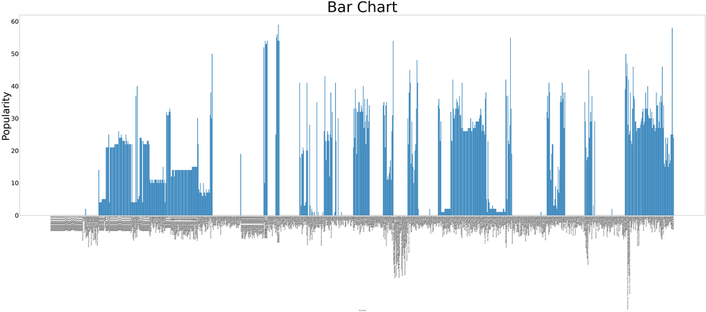

```python
import matplotlib.pyplot as plt
from matplotlib.pyplot import hist
import seaborn as sns
#hist=music.plot(x="Track_Name", y="Popularity", kind='hist')
plt.figure(figsize=(100,30))
plt.bar(music['Track_Name'], music['Popularity'], align='center')
plt.xlabel('Track_Name')
plt.xticks(rotation=90)
plt.ylabel('Popularity',fontsize=80)
plt.yticks(fontsize=50)
plt.title('Bar Chart',fontsize=120)
plt.show()
```

```python
#counted popularity
popularity_count=music.groupby('Track_Name')['Popularity'].count().sort_values(ascending=False)
popularity_count
```

```
Track_Name
Relaxing Sleep (Meditation Music)                                                                       23
1 Hour Relaxing Music for Stress Relief. Soothing Music. Meditation. Sleep Music                        17
Brown Noise for Restless Kids: 880 Hz                                                                   16
Down To Earth                                                                                           10
Relaxing Sleep Music • Deep Sleeping Music, Relaxing Music, Stress Relief, Meditation Music (Flying)    10
                                                                                                        ..
Long Road                                                                                                1
Lost in Thought                                                                                          1
Lotus Flower                                                                                             1
Lotus Relaxation                                                                                         1
涙活                                                                                                       1
Name: Popularity, Length: 940, dtype: int64
```

```python
#creating a dataframe with popularity count
popularity_mean_count= pd.DataFrame(music.groupby('Track_Name')['Popularity'].mean())
popularity_mean_count
```

| Track_Name | Popularity |
| --- | --- |
| 1 Hour Relaxing Music for Stress Relief. Soothing Music. Meditation. Sleep Music | 0.0 |
| 100 Years | 0.0 |
| 15 Minute Super Deep Meditation Music: Relax Mind Body, Inner Peace, Relaxing Music | 0.0 |
| 174 Hz: Letting Go Emotional & Physical Pain | 36.0 |
| 428HZ Frequency Healing Meditation Music | 0.0 |
| ... | ... |
| Zephyr Sings | 0.0 |
| Zona de Concentración | 15.0 |
| [Study Sleep Relax 💖] Meditation - music | 0.0 |
| Полная релаксация | 33.0 |
| 涙活 | 31.0 |

940 rows × 1 columns

```python
#adding popularity mean count to existing dataframe with popularity
popularity_mean_count['popularity_count'] = pd.DataFrame(music.groupby('Track_Name')['Popularity'].count())
```

```python
popularity_mean_count
```

| Track_Name | Popularity | popularity_count |
| --- | --- | --- |
| 1 Hour Relaxing Music for Stress Relief. Soothing Music. Meditation. Sleep Music | 0.0 | 17 |
| 100 Years | 0.0 | 1 |
| 15 Minute Super Deep Meditation Music: Relax Mind Body, Inner Peace, Relaxing Music | 0.0 | 3 |
| 174 Hz: Letting Go Emotional & Physical Pain | 36.0 | 1 |
| 428HZ Frequency Healing Meditation Music | 0.0 | 2 |
| ... | ... | ... |
| Zephyr Sings | 0.0 | 1 |
| Zona de Concentración | 15.0 | 1 |
| [Study Sleep Relax 💖] Meditation - music | 0.0 | 7 |
| Полная релаксация | 33.0 | 1 |
| 涙活 | 31.0 | 1 |

940 rows × 2 columns

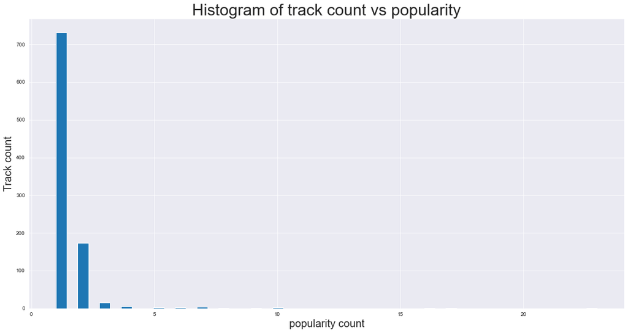

```python
sns.set_style('dark')
%matplotlib inline

plt.figure(figsize=(20,10))
plt.xlabel("popularity count", fontsize=20)
plt.ylabel("Track count", fontsize=20)
plt.title("Histogram of track count vs popularity", fontsize=30)
plt.rcParams['patch.force_edgecolor'] = True
popularity_mean_count['popularity_count'].hist(bins=50)
```

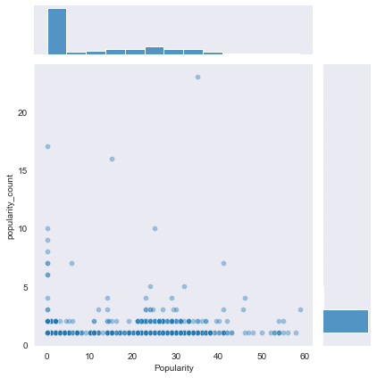

```python
#jointplot
plt.figure(figsize=(8,6))
plt.rcParams['patch.force_edgecolor'] = True
sns.jointplot(x='Popularity', y='popularity_count', data=popularity_mean_count, alpha=0.4)
```

## Top Ten Popular Songs

```python
#count how many rows we have by song, we show only the ten more popular songs
top_ten = music.groupby('Track_Name')['Popularity'].count().reset_index().sort_values(['Popularity', 'Track_Name'], ascending = [0,1])
top_ten['top_ten']  = round(top_ten['Popularity'].div(top_ten['Popularity'].sum())*100, 2)
```

```python
top_ten = top_ten[:10]
top_ten
```

|  | Track_Name | Popularity | top_ten |
| --- | --- | --- | --- |
| 692 | Relaxing Sleep (Meditation Music) | 23 | 1.79 |
| 0 | 1 Hour Relaxing Music for Stress Relief. Sooth... | 17 | 1.32 |
| 97 | Brown Noise for Restless Kids: 880 Hz | 16 | 1.24 |
| 180 | Down To Earth | 10 | 0.78 |
| 693 | Relaxing Sleep Music • Deep Sleeping Music, Re... | 10 | 0.78 |
| 819 | Study Music, Concentration, Focus, Meditation,... | 9 | 0.70 |
| 917 | Yoga Music, Relaxing Music, Calming Music, Str... | 8 | 0.62 |
| 37 | Art of Flying | 7 | 0.54 |
| 285 | Healing Sounds: Cleans the Aura and Space. Rem... | 7 | 0.54 |
| 365 | Meditating Music | 7 | 0.54 |

```python
labels = top_ten['Track_Name'].tolist()
counts = top_ten['Popularity'].tolist()
```

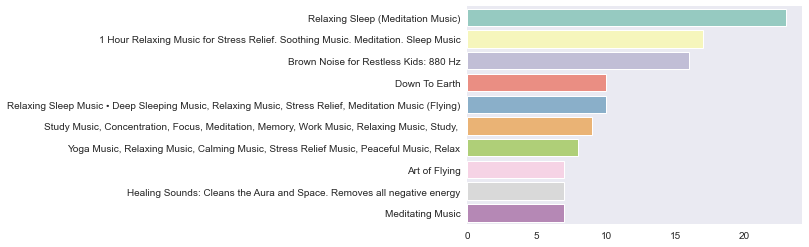

```python
plt.figure()
sns.barplot(x=counts, y=labels, palette='Set3')
sns.despine(left=True, bottom=True)
```

```python
pip install plotly
```

```python
import plotly.express as px
sound=px.data.gapminder()
sound_features=['Danceability', 'Energy', 'Key', 'Loudness', 'Mode', 'Speechiness', 'Acousticness', 'Instrumentalness', 'Liveness', 'Valence', 'Tempo']
figure=px.line(music, x="Album_Release_Date", y=sound_features)
figure.show()
```

[interactive chart not shown]

```python
# how many songs a user listend to
music_grouped=music.groupby(['user_id','Track_Name'])
music_grouped.first()
```

| user_id | Track_Name | Track_URI | Artist_Name | Album_Name | Album_Release_Date | Track_Number | Track_Duration(ms) | Explicit | Popularity | Added_By | Added_At | ... | Key | Loudness | Mode | Speechiness | Acousticness | Instrumentalness | Liveness | Valence | Tempo | Time_Signature |
| --- | --- | --- | --- | --- | --- | --- | --- | --- | --- | --- | --- | --- | --- | --- | --- | --- | --- | --- | --- | --- | --- | --- |
| 1 | Between Worlds, Native American | spotify:track:1B9OkJj4frUJjrqH6dCd7x | Oriental Music Zone | Indian Meditation Music Collection – Instrumen... | 2017-08-21 | 17 | 235887 | False | 1 | spotify:user:31hmjzhlbj4ehjd6qrmh7v4rv6oi | 2022-02-15 | ... | 1.000000 | -26.973000 | 0.000000 | 0.046900 | 0.938000 | 0.970000 | 0.096700 | 0.129000 | 137.553000 | 3 |
|  | Power Of Peace - Original Mix | spotify:track:7ilBLFs3Q9Mb3xa6si2ICT | Sanct Devotional Club | Mindful Valley - Relaxing Meditating Music | 2021-05-26 | 31 | 185600 | False | 0 | spotify:user:31hmjzhlbj4ehjd6qrmh7v4rv6oi | 2022-02-15 | ... | 1.000000 | -14.974000 | 1.000000 | 0.044100 | 0.656000 | 0.956000 | 0.112000 | 0.036700 | 62.693000 | 3 |
|  | Relaxation Therapy Music | spotify:track:5LkuuUwdyM6cqx0RTMlqTZ | Five Senses Meditation Sanctuary | Modern Meditation: Fast and Effective Relaxation | 2019-08-12 | 3 | 203576 | False | 32 | spotify:user:31hmjzhlbj4ehjd6qrmh7v4rv6oi | 2022-02-12 | ... | 10.000000 | -17.750000 | 1.000000 | 0.036400 | 0.989000 | 0.943000 | 0.079500 | 0.274000 | 77.978000 | 4 |
|  | Sleep Aid Noise: 720 Hz | spotify:track:3xEcxC4SJKbl2kBrhzmNmL | Brown Noise Nuts | Brown Noise: 720 Hz | 2021-11-15 | 19 | 62000 | False | 14 | spotify:user:31hmjzhlbj4ehjd6qrmh7v4rv6oi | 2022-02-12 | ... | 4.766784 | -25.155986 | 0.675795 | 0.061512 | 0.831158 | 0.798753 | 0.185348 | 0.093422 | 96.196466 | 4 |
|  | Sleeping Flute Music | spotify:track:1lIikO2A66vDn2uwR3UZNt | Deep Sleep Music DEA Channel, Flute Music Medi... | Healing Indian Flute: Calming Native American ... | 2021-12-16 | 1 | 165233 | False | 6 | spotify:user:31hmjzhlbj4ehjd6qrmh7v4rv6oi | 2022-02-15 | ... | 0.000000 | -16.700000 | 1.000000 | 0.041500 | 0.986000 | 0.915000 | 0.106000 | 0.040400 | 62.264000 | 3 |
| ... | ... | ... | ... | ... | ... | ... | ... | ... | ... | ... | ... | ... | ... | ... | ... | ... | ... | ... | ... | ... | ... | ... |
| 98 | Indian Flute Music For Deep Meditation, Relaxation ,Inner Peace, Yoga And Spa | spotify:episode:6woGmcr5A67MkTa1uG4sdV | Prana Relaxation And Meditation Music | Prana Relaxation And Meditation Music | 2019-01-12 | 0 | 2827050 | False | 0 | spotify:user:31hmjzhlbj4ehjd6qrmh7v4rv6oi | 2022-02-15 | ... | 4.766784 | -25.155986 | 0.675795 | 0.061512 | 0.831158 | 0.798753 | 0.185348 | 0.093422 | 96.196466 | 4 |
|  | Reiki Zen Meditation Music,Healing Music, Positive Motivating Energy | spotify:episode:73pCD0cQV3KPJERUL8m0bK | MEDITATION SELF | MEDITATION SELF | 2019-01-12 | 0 | 3608217 | False | 0 | spotify:user:31hmjzhlbj4ehjd6qrmh7v4rv6oi | 2022-02-12 | ... | 4.766784 | -25.155986 | 0.675795 | 0.061512 | 0.831158 | 0.798753 | 0.185348 | 0.093422 | 96.196466 | 4 |
|  | Sarvesham Svastir Bhavtu | spotify:track:0ttVqRISNySDktBhdJsJZv | Meditative Mind | Magical Mantras for Meditation - Volume Two | 2015-11-30 | 4 | 2717900 | False | 39 | spotify:user:31hmjzhlbj4ehjd6qrmh7v4rv6oi | 2022-02-15 | ... | 0.000000 | -21.798000 | 1.000000 | 0.036800 | 0.892000 | 0.195000 | 0.089200 | 0.031500 | 102.618000 | 4 |
| 99 | Meditation on the Beach | spotify:track:2jtYyevrJUjP5WoUZ47zmA | Buddha Music Sanctuary | Meditation TOP 100: Buddha Calm & Peace, 7 Cha... | 2016-01-19 | 44 | 217282 | False | 0 | spotify:user:31hmjzhlbj4ehjd6qrmh7v4rv6oi | 2022-02-12 | ... | 11.000000 | -27.510000 | 1.000000 | 0.081600 | 0.942000 | 0.001740 | 0.333000 | 0.038300 | 103.135000 | 4 |
|  | Pure Feelings | spotify:track:2k4sKrKjj8STfBg0gTco4P | Relaxing Saxophone Jazz | Meditating Saxophone Music | 2020-07-14 | 8 | 159394 | False | 18 | spotify:user:31hmjzhlbj4ehjd6qrmh7v4rv6oi | 2022-02-15 | ... | 9.000000 | -19.544000 | 0.000000 | 0.067500 | 0.962000 | 0.027900 | 0.135000 | 0.584000 | 183.320000 | 3 |

1279 rows × 22 columns

# Finding Similarities of Users by Pivot Table

```python
music_pivot=music.pivot_table(index='user_id',columns='Track_Name', values='Popularity').reset_index(drop=True)
music_pivot
```

| Track_Name | 1 Hour Relaxing Music for Stress Relief. Soothing Music. Meditation. Sleep Music | 100 Years | 15 Minute Super Deep Meditation Music: Relax Mind Body, Inner Peace, Relaxing Music | 174 Hz: Letting Go Emotional & Physical Pain | 428HZ Frequency Healing Meditation Music | 528Hz The Miracle Tone | A Gentle Raindop | A New Day | A New You | A Precious Moment - Original Mix | ... | Zen Music Sleep Trigger | Zen Spa Music Relaxation | Zen Spiritual Music | Zen Stones | Zendo | Zephyr Sings | Zona de Concentración | [Study Sleep Relax 💖] Meditation - music | Полная релаксация | 涙活 |
| --- | --- | --- | --- | --- | --- | --- | --- | --- | --- | --- | --- | --- | --- | --- | --- | --- | --- | --- | --- | --- | --- |
| 0 | NaN | NaN | NaN | NaN | NaN | NaN | NaN | NaN | NaN | NaN | ... | NaN | NaN | NaN | NaN | NaN | NaN | NaN | NaN | NaN | NaN |
| 1 | NaN | NaN | NaN | NaN | NaN | NaN | NaN | NaN | NaN | NaN | ... | NaN | NaN | NaN | NaN | NaN | NaN | NaN | NaN | NaN | NaN |
| 2 | NaN | NaN | 0.0 | NaN | NaN | NaN | NaN | NaN | NaN | NaN | ... | NaN | NaN | NaN | NaN | NaN | NaN | NaN | NaN | NaN | NaN |
| 3 | NaN | NaN | NaN | NaN | NaN | NaN | NaN | NaN | NaN | NaN | ... | NaN | NaN | NaN | 0.0 | NaN | NaN | NaN | NaN | NaN | NaN |
| 4 | NaN | NaN | NaN | NaN | NaN | NaN | NaN | NaN | NaN | NaN | ... | NaN | NaN | NaN | NaN | NaN | NaN | NaN | NaN | NaN | NaN |
| ... | ... | ... | ... | ... | ... | ... | ... | ... | ... | ... | ... | ... | ... | ... | ... | ... | ... | ... | ... | ... | ... |
| 145 | NaN | NaN | NaN | NaN | NaN | NaN | NaN | NaN | NaN | NaN | ... | NaN | NaN | NaN | NaN | NaN | NaN | NaN | NaN | NaN | NaN |
| 146 | NaN | NaN | NaN | NaN | NaN | NaN | NaN | NaN | NaN | NaN | ... | NaN | NaN | NaN | NaN | NaN | NaN | NaN | NaN | NaN | NaN |
| 147 | NaN | NaN | NaN | NaN | NaN | NaN | NaN | NaN | NaN | NaN | ... | NaN | NaN | NaN | NaN | NaN | NaN | NaN | NaN | NaN | NaN |
| 148 | NaN | NaN | NaN | NaN | NaN | NaN | NaN | NaN | NaN | NaN | ... | NaN | NaN | NaN | NaN | NaN | NaN | NaN | NaN | NaN | NaN |
| 149 | NaN | NaN | NaN | NaN | NaN | NaN | NaN | NaN | NaN | NaN | ... | NaN | NaN | NaN | NaN | NaN | NaN | NaN | NaN | NaN | NaN |

150 rows × 940 columns

```python
# Impute those NaNs with 0 values
music_pivot.fillna(0,inplace=True)
music_pivot
```

| Track_Name | 1 Hour Relaxing Music for Stress Relief. Soothing Music. Meditation. Sleep Music | 100 Years | 15 Minute Super Deep Meditation Music: Relax Mind Body, Inner Peace, Relaxing Music | 174 Hz: Letting Go Emotional & Physical Pain | 428HZ Frequency Healing Meditation Music | 528Hz The Miracle Tone | A Gentle Raindop | A New Day | A New You | A Precious Moment - Original Mix | ... | Zen Music Sleep Trigger | Zen Spa Music Relaxation | Zen Spiritual Music | Zen Stones | Zendo | Zephyr Sings | Zona de Concentración | [Study Sleep Relax 💖] Meditation - music | Полная релаксация | 涙活 |
| --- | --- | --- | --- | --- | --- | --- | --- | --- | --- | --- | --- | --- | --- | --- | --- | --- | --- | --- | --- | --- | --- |
| 0 | 0.0 | 0.0 | 0.0 | 0.0 | 0.0 | 0.0 | 0.0 | 0.0 | 0.0 | 0.0 | ... | 0.0 | 0.0 | 0.0 | 0.0 | 0.0 | 0.0 | 0.0 | 0.0 | 0.0 | 0.0 |
| 1 | 0.0 | 0.0 | 0.0 | 0.0 | 0.0 | 0.0 | 0.0 | 0.0 | 0.0 | 0.0 | ... | 0.0 | 0.0 | 0.0 | 0.0 | 0.0 | 0.0 | 0.0 | 0.0 | 0.0 | 0.0 |
| 2 | 0.0 | 0.0 | 0.0 | 0.0 | 0.0 | 0.0 | 0.0 | 0.0 | 0.0 | 0.0 | ... | 0.0 | 0.0 | 0.0 | 0.0 | 0.0 | 0.0 | 0.0 | 0.0 | 0.0 | 0.0 |
| 3 | 0.0 | 0.0 | 0.0 | 0.0 | 0.0 | 0.0 | 0.0 | 0.0 | 0.0 | 0.0 | ... | 0.0 | 0.0 | 0.0 | 0.0 | 0.0 | 0.0 | 0.0 | 0.0 | 0.0 | 0.0 |
| 4 | 0.0 | 0.0 | 0.0 | 0.0 | 0.0 | 0.0 | 0.0 | 0.0 | 0.0 | 0.0 | ... | 0.0 | 0.0 | 0.0 | 0.0 | 0.0 | 0.0 | 0.0 | 0.0 | 0.0 | 0.0 |
| ... | ... | ... | ... | ... | ... | ... | ... | ... | ... | ... | ... | ... | ... | ... | ... | ... | ... | ... | ... | ... | ... |
| 145 | 0.0 | 0.0 | 0.0 | 0.0 | 0.0 | 0.0 | 0.0 | 0.0 | 0.0 | 0.0 | ... | 0.0 | 0.0 | 0.0 | 0.0 | 0.0 | 0.0 | 0.0 | 0.0 | 0.0 | 0.0 |
| 146 | 0.0 | 0.0 | 0.0 | 0.0 | 0.0 | 0.0 | 0.0 | 0.0 | 0.0 | 0.0 | ... | 0.0 | 0.0 | 0.0 | 0.0 | 0.0 | 0.0 | 0.0 | 0.0 | 0.0 | 0.0 |
| 147 | 0.0 | 0.0 | 0.0 | 0.0 | 0.0 | 0.0 | 0.0 | 0.0 | 0.0 | 0.0 | ... | 0.0 | 0.0 | 0.0 | 0.0 | 0.0 | 0.0 | 0.0 | 0.0 | 0.0 | 0.0 |
| 148 | 0.0 | 0.0 | 0.0 | 0.0 | 0.0 | 0.0 | 0.0 | 0.0 | 0.0 | 0.0 | ... | 0.0 | 0.0 | 0.0 | 0.0 | 0.0 | 0.0 | 0.0 | 0.0 | 0.0 | 0.0 |
| 149 | 0.0 | 0.0 | 0.0 | 0.0 | 0.0 | 0.0 | 0.0 | 0.0 | 0.0 | 0.0 | ... | 0.0 | 0.0 | 0.0 | 0.0 | 0.0 | 0.0 | 0.0 | 0.0 | 0.0 | 0.0 |

150 rows × 940 columns

```python
from sklearn.metrics import pairwise_distances
from scipy.spatial.distance import cosine,correlation
```

```python
# Calculating Cosine Similarity between Users on array data
music_sim=1-pairwise_distances(music_pivot.values,metric='cosine')
music_sim
```

```
array([[1., 0., 0., ..., 0., 0., 0.],
       [0., 1., 0., ..., 0., 0., 0.],
       [0., 0., 1., ..., 0., 0., 0.],
       ...,
       [0., 0., 0., ..., 1., 0., 0.],
       [0., 0., 0., ..., 0., 1., 0.],
       [0., 0., 0., ..., 0., 0., 1.]])
```

```python
# Store the results in a dataframe format
music_sim1=pd.DataFrame(music_sim)
music_sim1
```

|  | 0 | 1 | 2 | 3 | 4 | 5 | 6 | 7 | 8 | 9 | ... | 140 | 141 | 142 | 143 | 144 | 145 | 146 | 147 | 148 | 149 |
| --- | --- | --- | --- | --- | --- | --- | --- | --- | --- | --- | --- | --- | --- | --- | --- | --- | --- | --- | --- | --- | --- |
| 0 | 1.0 | 0.0 | 0.0 | 0.0 | 0.0 | 0.0 | 0.0 | 0.000000 | 0.0 | 0.000000 | ... | 0.0 | 0.0 | 0.000000 | 0.0 | 0.0 | 0.0 | 0.0 | 0.0 | 0.0 | 0.0 |
| 1 | 0.0 | 1.0 | 0.0 | 0.0 | 0.0 | 0.0 | 0.0 | 0.000000 | 0.0 | 0.000000 | ... | 0.0 | 0.0 | 0.000000 | 0.0 | 0.0 | 0.0 | 0.0 | 0.0 | 0.0 | 0.0 |
| 2 | 0.0 | 0.0 | 1.0 | 0.0 | 0.0 | 0.0 | 0.0 | 0.000000 | 0.0 | 0.000000 | ... | 0.0 | 0.0 | 0.000000 | 0.0 | 0.0 | 0.0 | 0.0 | 0.0 | 0.0 | 0.0 |
| 3 | 0.0 | 0.0 | 0.0 | 1.0 | 0.0 | 0.0 | 0.0 | 0.000000 | 0.0 | 0.000000 | ... | 0.0 | 0.0 | 0.000000 | 0.0 | 0.0 | 0.0 | 0.0 | 0.0 | 0.0 | 0.0 |
| 4 | 0.0 | 0.0 | 0.0 | 0.0 | 1.0 | 0.0 | 0.0 | 0.078534 | 0.0 | 0.000000 | ... | 0.0 | 0.0 | 0.000000 | 0.0 | 0.0 | 0.0 | 0.0 | 0.0 | 0.0 | 0.0 |
| ... | ... | ... | ... | ... | ... | ... | ... | ... | ... | ... | ... | ... | ... | ... | ... | ... | ... | ... | ... | ... | ... |
| 145 | 0.0 | 0.0 | 0.0 | 0.0 | 0.0 | 0.0 | 0.0 | 0.000000 | 0.0 | 0.000000 | ... | 0.0 | 0.0 | 0.000000 | 0.0 | 0.0 | 1.0 | 0.0 | 0.0 | 0.0 | 0.0 |
| 146 | 0.0 | 0.0 | 0.0 | 0.0 | 0.0 | 0.0 | 0.0 | 0.000000 | 0.0 | 0.211915 | ... | 0.0 | 0.0 | 0.482729 | 0.0 | 0.0 | 0.0 | 1.0 | 0.0 | 0.0 | 0.0 |
| 147 | 0.0 | 0.0 | 0.0 | 0.0 | 0.0 | 0.0 | 0.0 | 0.000000 | 0.0 | 0.000000 | ... | 0.0 | 0.0 | 0.000000 | 0.0 | 0.0 | 0.0 | 0.0 | 1.0 | 0.0 | 0.0 |
| 148 | 0.0 | 0.0 | 0.0 | 0.0 | 0.0 | 0.0 | 0.0 | 0.000000 | 0.0 | 0.000000 | ... | 0.0 | 0.0 | 0.000000 | 0.0 | 0.0 | 0.0 | 0.0 | 0.0 | 1.0 | 0.0 |
| 149 | 0.0 | 0.0 | 0.0 | 0.0 | 0.0 | 0.0 | 0.0 | 0.000000 | 0.0 | 0.000000 | ... | 0.0 | 0.0 | 0.000000 | 0.0 | 0.0 | 0.0 | 0.0 | 0.0 | 0.0 | 1.0 |

150 rows × 150 columns

```python
# Set the index and column names to music ids
#similarity of each users individually
music_sim1.index=music['user_id'].unique()
music_sim1.columns=music['user_id'].unique()
music_sim1
```

|  | 2 | 30 | 53 | 86 | 130 | 97 | 22 | 133 | 28 | 12 | ... | 99 | 19 | 65 | 88 | 37 | 109 | 128 | 104 | 98 | 21 |
| --- | --- | --- | --- | --- | --- | --- | --- | --- | --- | --- | --- | --- | --- | --- | --- | --- | --- | --- | --- | --- | --- |
| 2 | 1.0 | 0.0 | 0.0 | 0.0 | 0.0 | 0.0 | 0.0 | 0.000000 | 0.0 | 0.000000 | ... | 0.0 | 0.0 | 0.000000 | 0.0 | 0.0 | 0.0 | 0.0 | 0.0 | 0.0 | 0.0 |
| 30 | 0.0 | 1.0 | 0.0 | 0.0 | 0.0 | 0.0 | 0.0 | 0.000000 | 0.0 | 0.000000 | ... | 0.0 | 0.0 | 0.000000 | 0.0 | 0.0 | 0.0 | 0.0 | 0.0 | 0.0 | 0.0 |
| 53 | 0.0 | 0.0 | 1.0 | 0.0 | 0.0 | 0.0 | 0.0 | 0.000000 | 0.0 | 0.000000 | ... | 0.0 | 0.0 | 0.000000 | 0.0 | 0.0 | 0.0 | 0.0 | 0.0 | 0.0 | 0.0 |
| 86 | 0.0 | 0.0 | 0.0 | 1.0 | 0.0 | 0.0 | 0.0 | 0.000000 | 0.0 | 0.000000 | ... | 0.0 | 0.0 | 0.000000 | 0.0 | 0.0 | 0.0 | 0.0 | 0.0 | 0.0 | 0.0 |
| 130 | 0.0 | 0.0 | 0.0 | 0.0 | 1.0 | 0.0 | 0.0 | 0.078534 | 0.0 | 0.000000 | ... | 0.0 | 0.0 | 0.000000 | 0.0 | 0.0 | 0.0 | 0.0 | 0.0 | 0.0 | 0.0 |
| ... | ... | ... | ... | ... | ... | ... | ... | ... | ... | ... | ... | ... | ... | ... | ... | ... | ... | ... | ... | ... | ... |
| 109 | 0.0 | 0.0 | 0.0 | 0.0 | 0.0 | 0.0 | 0.0 | 0.000000 | 0.0 | 0.000000 | ... | 0.0 | 0.0 | 0.000000 | 0.0 | 0.0 | 1.0 | 0.0 | 0.0 | 0.0 | 0.0 |
| 128 | 0.0 | 0.0 | 0.0 | 0.0 | 0.0 | 0.0 | 0.0 | 0.000000 | 0.0 | 0.211915 | ... | 0.0 | 0.0 | 0.482729 | 0.0 | 0.0 | 0.0 | 1.0 | 0.0 | 0.0 | 0.0 |
| 104 | 0.0 | 0.0 | 0.0 | 0.0 | 0.0 | 0.0 | 0.0 | 0.000000 | 0.0 | 0.000000 | ... | 0.0 | 0.0 | 0.000000 | 0.0 | 0.0 | 0.0 | 0.0 | 1.0 | 0.0 | 0.0 |
| 98 | 0.0 | 0.0 | 0.0 | 0.0 | 0.0 | 0.0 | 0.0 | 0.000000 | 0.0 | 0.000000 | ... | 0.0 | 0.0 | 0.000000 | 0.0 | 0.0 | 0.0 | 0.0 | 0.0 | 1.0 | 0.0 |
| 21 | 0.0 | 0.0 | 0.0 | 0.0 | 0.0 | 0.0 | 0.0 | 0.000000 | 0.0 | 0.000000 | ... | 0.0 | 0.0 | 0.000000 | 0.0 | 0.0 | 0.0 | 0.0 | 0.0 | 0.0 | 1.0 |

150 rows × 150 columns

```python
#every user is similar to themselves so not considering it
# Nullifying diagonal values
np.fill_diagonal(music_sim,0)
music_sim1
```

|  | 2 | 30 | 53 | 86 | 130 | 97 | 22 | 133 | 28 | 12 | ... | 99 | 19 | 65 | 88 | 37 | 109 | 128 | 104 | 98 | 21 |
| --- | --- | --- | --- | --- | --- | --- | --- | --- | --- | --- | --- | --- | --- | --- | --- | --- | --- | --- | --- | --- | --- |
| 2 | 0.0 | 0.0 | 0.0 | 0.0 | 0.0 | 0.0 | 0.0 | 0.000000 | 0.0 | 0.000000 | ... | 0.0 | 0.0 | 0.000000 | 0.0 | 0.0 | 0.0 | 0.0 | 0.0 | 0.0 | 0.0 |
| 30 | 0.0 | 0.0 | 0.0 | 0.0 | 0.0 | 0.0 | 0.0 | 0.000000 | 0.0 | 0.000000 | ... | 0.0 | 0.0 | 0.000000 | 0.0 | 0.0 | 0.0 | 0.0 | 0.0 | 0.0 | 0.0 |
| 53 | 0.0 | 0.0 | 0.0 | 0.0 | 0.0 | 0.0 | 0.0 | 0.000000 | 0.0 | 0.000000 | ... | 0.0 | 0.0 | 0.000000 | 0.0 | 0.0 | 0.0 | 0.0 | 0.0 | 0.0 | 0.0 |
| 86 | 0.0 | 0.0 | 0.0 | 0.0 | 0.0 | 0.0 | 0.0 | 0.000000 | 0.0 | 0.000000 | ... | 0.0 | 0.0 | 0.000000 | 0.0 | 0.0 | 0.0 | 0.0 | 0.0 | 0.0 | 0.0 |
| 130 | 0.0 | 0.0 | 0.0 | 0.0 | 0.0 | 0.0 | 0.0 | 0.078534 | 0.0 | 0.000000 | ... | 0.0 | 0.0 | 0.000000 | 0.0 | 0.0 | 0.0 | 0.0 | 0.0 | 0.0 | 0.0 |
| ... | ... | ... | ... | ... | ... | ... | ... | ... | ... | ... | ... | ... | ... | ... | ... | ... | ... | ... | ... | ... | ... |
| 109 | 0.0 | 0.0 | 0.0 | 0.0 | 0.0 | 0.0 | 0.0 | 0.000000 | 0.0 | 0.000000 | ... | 0.0 | 0.0 | 0.000000 | 0.0 | 0.0 | 0.0 | 0.0 | 0.0 | 0.0 | 0.0 |
| 128 | 0.0 | 0.0 | 0.0 | 0.0 | 0.0 | 0.0 | 0.0 | 0.000000 | 0.0 | 0.211915 | ... | 0.0 | 0.0 | 0.482729 | 0.0 | 0.0 | 0.0 | 0.0 | 0.0 | 0.0 | 0.0 |
| 104 | 0.0 | 0.0 | 0.0 | 0.0 | 0.0 | 0.0 | 0.0 | 0.000000 | 0.0 | 0.000000 | ... | 0.0 | 0.0 | 0.000000 | 0.0 | 0.0 | 0.0 | 0.0 | 0.0 | 0.0 | 0.0 |
| 98 | 0.0 | 0.0 | 0.0 | 0.0 | 0.0 | 0.0 | 0.0 | 0.000000 | 0.0 | 0.000000 | ... | 0.0 | 0.0 | 0.000000 | 0.0 | 0.0 | 0.0 | 0.0 | 0.0 | 0.0 | 0.0 |
| 21 | 0.0 | 0.0 | 0.0 | 0.0 | 0.0 | 0.0 | 0.0 | 0.000000 | 0.0 | 0.000000 | ... | 0.0 | 0.0 | 0.000000 | 0.0 | 0.0 | 0.0 | 0.0 | 0.0 | 0.0 | 0.0 |

150 rows × 150 columns

```python
# displaying Most Similar Users
music_sim1.idxmax(axis=1)
```

```
2       56
30     125
53       2
86     124
130     64
      ...
109    149
128     65
104      2
98     136
21       2
Length: 150, dtype: object
```

```python
music1=music.sort_index()
music1
```

|  | user_id | Track_URI | Track_Name | Artist_Name | Album_Name | Album_Release_Date | Track_Number | Track_Duration(ms) | Explicit | Popularity | ... | Key | Loudness | Mode | Speechiness | Acousticness | Instrumentalness | Liveness | Valence | Tempo | Time_Signature |
| --- | --- | --- | --- | --- | --- | --- | --- | --- | --- | --- | --- | --- | --- | --- | --- | --- | --- | --- | --- | --- | --- |
| 0 | 41 | spotify:track:4wDkM4eonFlMpw07mQxZbM | Meditation Awaken | Chakra Healing Music Academy | Genius Brain Frequency: Top 100 Chakra Healing... | 2022-01-04 | 20 | 225000 | False | 5 | ... | 0.000000 | -23.311000 | 1.000000 | 0.036600 | 0.986000 | 0.872000 | 0.088400 | 0.036800 | 75.166000 | 4 |
| 1 | 29 | spotify:track:0dLkW1wbEi6nzyLQOwNCMv | Yoga Top 100 | Yoga Training Music Ensemble, Healing Yoga Med... | Anxiety Meditation and Yoga for Insecurity: Re... | 2021-09-07 | 3 | 255384 | False | 1 | ... | 5.000000 | -22.049000 | 1.000000 | 0.049900 | 0.922000 | 0.917000 | 0.101000 | 0.037200 | 88.407000 | 4 |
| 2 | 102 | spotify:episode:6tpsPNJECk1eLbsPJgXNBR | Meditation - Naval Ravikant | Self Improvement through Top 100 Books | Self Improvement through Top 100 Books | 2019-01-12 | 0 | 415056 | False | 0 | ... | 4.766784 | -25.155986 | 0.675795 | 0.061512 | 0.831158 | 0.798753 | 0.185348 | 0.093422 | 96.196466 | 4 |
| 3 | 150 | spotify:track:1oVgCauMXygkALiOtI51M1 | Yoga Top 100 | Namaste Healing Yoga | Zen Meditation Music 111: Relaxing Flute Piano... | 2016-05-23 | 25 | 252512 | False | 8 | ... | 10.000000 | -24.113000 | 1.000000 | 0.042100 | 0.843000 | 0.947000 | 0.130000 | 0.053400 | 102.475000 | 3 |
| 4 | 8 | spotify:episode:5fLpnfOalU991SfSu9r7z8 | Meditation - by A Monk | Self Improvement through Top 100 Books | Self Improvement through Top 100 Books | 2019-01-12 | 0 | 112941 | False | 0 | ... | 4.766784 | -25.155986 | 0.675795 | 0.061512 | 0.831158 | 0.798753 | 0.185348 | 0.093422 | 96.196466 | 4 |
| ... | ... | ... | ... | ... | ... | ... | ... | ... | ... | ... | ... | ... | ... | ... | ... | ... | ... | ... | ... | ... | ... |
| 1282 | 136 | spotify:track:52bpdusCUIPfzrRZ8n4FRP | Maitri | Yoga Ambience, Soothing White Noise for Infant... | # Fresh Therapy | 2019-10-09 | 26 | 346402 | False | 0 | ... | 2.000000 | -18.944000 | 1.000000 | 0.042400 | 0.929000 | 0.954000 | 0.092200 | 0.038400 | 70.205000 | 5 |
| 1283 | 133 | spotify:track:71kayL70PNWQIHWt5P8uhU | Spiritual Teacher | Yoga Ambience, Soothing White Noise for Infant... | # Fresh Therapy | 2019-10-09 | 27 | 285372 | False | 0 | ... | 2.000000 | -20.522000 | 0.000000 | 0.043300 | 0.991000 | 0.989000 | 0.085100 | 0.034000 | 75.706000 | 3 |
| 1284 | 45 | spotify:track:77PyhSbcu8ctjPbVGSwaa9 | Chakra | Yoga Ambience, Soothing White Noise for Infant... | # Fresh Therapy | 2019-10-09 | 28 | 272816 | False | 0 | ... | 11.000000 | -29.692000 | 0.000000 | 0.044600 | 0.968000 | 0.975000 | 0.137000 | 0.034200 | 64.739000 | 3 |
| 1285 | 64 | spotify:track:3vmjzmOGGlPczWQWNf7cE0 | Elixir | Yoga Ambience, Soothing White Noise for Infant... | # Fresh Therapy | 2019-10-09 | 29 | 253226 | False | 0 | ... | 10.000000 | -21.052000 | 0.000000 | 0.076900 | 0.990000 | 0.915000 | 0.129000 | 0.049200 | 65.566000 | 5 |
| 1286 | 36 | spotify:track:5AJIr4CC0Te4HOofAtmYa8 | Kundalini | Yoga Ambience, Soothing White Noise for Infant... | # Fresh Therapy | 2019-10-09 | 30 | 245496 | False | 0 | ... | 3.000000 | -28.018000 | 1.000000 | 0.038700 | 0.982000 | 0.986000 | 0.115000 | 0.049600 | 68.935000 | 4 |

1287 rows × 24 columns

```python
music1.head(10)
```

|  | user_id | Track_URI | Track_Name | Artist_Name | Album_Name | Album_Release_Date | Track_Number | Track_Duration(ms) | Explicit | Popularity | ... | Key | Loudness | Mode | Speechiness | Acousticness | Instrumentalness | Liveness | Valence | Tempo | Time_Signature |
| --- | --- | --- | --- | --- | --- | --- | --- | --- | --- | --- | --- | --- | --- | --- | --- | --- | --- | --- | --- | --- | --- |
| 0 | 41 | spotify:track:4wDkM4eonFlMpw07mQxZbM | Meditation Awaken | Chakra Healing Music Academy | Genius Brain Frequency: Top 100 Chakra Healing... | 2022-01-04 | 20 | 225000 | False | 5 | ... | 0.000000 | -23.311000 | 1.000000 | 0.036600 | 0.986000 | 0.872000 | 0.088400 | 0.036800 | 75.166000 | 4 |
| 1 | 29 | spotify:track:0dLkW1wbEi6nzyLQOwNCMv | Yoga Top 100 | Yoga Training Music Ensemble, Healing Yoga Med... | Anxiety Meditation and Yoga for Insecurity: Re... | 2021-09-07 | 3 | 255384 | False | 1 | ... | 5.000000 | -22.049000 | 1.000000 | 0.049900 | 0.922000 | 0.917000 | 0.101000 | 0.037200 | 88.407000 | 4 |
| 2 | 102 | spotify:episode:6tpsPNJECk1eLbsPJgXNBR | Meditation - Naval Ravikant | Self Improvement through Top 100 Books | Self Improvement through Top 100 Books | 2019-01-12 | 0 | 415056 | False | 0 | ... | 4.766784 | -25.155986 | 0.675795 | 0.061512 | 0.831158 | 0.798753 | 0.185348 | 0.093422 | 96.196466 | 4 |
| 3 | 150 | spotify:track:1oVgCauMXygkALiOtI51M1 | Yoga Top 100 | Namaste Healing Yoga | Zen Meditation Music 111: Relaxing Flute Piano... | 2016-05-23 | 25 | 252512 | False | 8 | ... | 10.000000 | -24.113000 | 1.000000 | 0.042100 | 0.843000 | 0.947000 | 0.130000 | 0.053400 | 102.475000 | 3 |
| 4 | 8 | spotify:episode:5fLpnfOalU991SfSu9r7z8 | Meditation - by A Monk | Self Improvement through Top 100 Books | Self Improvement through Top 100 Books | 2019-01-12 | 0 | 112941 | False | 0 | ... | 4.766784 | -25.155986 | 0.675795 | 0.061512 | 0.831158 | 0.798753 | 0.185348 | 0.093422 | 96.196466 | 4 |
| 5 | 68 | spotify:episode:6tpsPNJECk1eLbsPJgXNBR | Meditation - Naval Ravikant | Self Improvement through Top 100 Books | Self Improvement through Top 100 Books | 2019-01-12 | 0 | 415056 | False | 0 | ... | 4.766784 | -25.155986 | 0.675795 | 0.061512 | 0.831158 | 0.798753 | 0.185348 | 0.093422 | 96.196466 | 4 |
| 6 | 12 | spotify:track:2sC671jfJK3yoXUchjBjT5 | Buddha Meditation | Buddha Music Sanctuary | Meditation TOP 100: Buddha Calm & Peace, 7 Cha... | 2016-01-19 | 1 | 168630 | False | 2 | ... | 11.000000 | -20.416000 | 1.000000 | 0.042900 | 0.080600 | 0.783000 | 0.103000 | 0.036100 | 113.503000 | 5 |
| 7 | 143 | spotify:track:0SlkoLU94Jb9QeuchdOXWi | Mindscape | Buddha Music Sanctuary | Meditation TOP 100: Buddha Calm & Peace, 7 Cha... | 2016-01-19 | 2 | 189806 | False | 0 | ... | 9.000000 | -21.898000 | 1.000000 | 0.049200 | 0.981000 | 0.390000 | 0.110000 | 0.174000 | 124.294000 | 4 |
| 8 | 97 | spotify:track:0SlkoLU94Jb9QeuchdOXWi | Mindscape | Buddha Music Sanctuary | Meditation TOP 100: Buddha Calm & Peace, 7 Cha... | 2016-01-19 | 2 | 189806 | False | 0 | ... | 9.000000 | -21.898000 | 1.000000 | 0.049200 | 0.981000 | 0.390000 | 0.110000 | 0.174000 | 124.294000 | 4 |
| 9 | 11 | spotify:track:4N0V2ATgQAWZM4mqzv3gUL | Drifting Spirit: Journey to Peace | Buddha Music Sanctuary | Meditation TOP 100: Buddha Calm & Peace, 7 Cha... | 2016-01-19 | 5 | 205609 | False | 0 | ... | 6.000000 | -27.497000 | 0.000000 | 0.746000 | 0.913000 | 0.271000 | 0.201000 | 0.080200 | 107.068000 | 3 |

10 rows × 24 columns

## PCA

```python
from sklearn.decomposition import PCA
```

```python
# define transform
pca = PCA(n_components=1)
# prepare transform on dataset
pca.fit(music.iloc[:,12:23])
# apply transform to dataset
transformed = pca.transform(music.iloc[:,12:23])
```

```python
transformed
```

```
array([[ 21.82693979],
       [-44.89886907],
       [ -1.97957606],
       ...,
       [-26.42445821],
       [ 32.63863824],
       [  2.00743197]])
```

```python
pca.components_
```

```
array([[-9.64888128e-04, -4.19265298e-04,  7.92261009e-04,
        -3.37474395e-02,  1.70250420e-04, -8.11714580e-05,
         9.75293893e-04,  9.07587599e-04, -1.21486284e-04,
        -3.37993592e-04, -9.99428555e-01]])
```

```python
# Final Dataframe
final_df=pd.DataFrame(transformed)
final_df
```

|  | 0 |
| --- | --- |
| 0 | 21.826940 |
| 1 | -44.898869 |
| 2 | -1.979576 |
| 3 | 30.053730 |
| 4 | 12.370387 |
| ... | ... |
| 1282 | 12.849060 |
| 1283 | 19.096775 |
| 1284 | -26.424458 |
| 1285 | 32.638638 |
| 1286 | 2.007432 |

1287 rows × 1 columns

```python
pca1= final_df.rename(columns={0: 'PC1'})
pca1
```

|  | PC1 |
| --- | --- |
| 0 | 21.826940 |
| 1 | -44.898869 |
| 2 | -1.979576 |
| 3 | 30.053730 |
| 4 | 12.370387 |
| ... | ... |
| 1282 | 12.849060 |
| 1283 | 19.096775 |
| 1284 | -26.424458 |
| 1285 | 32.638638 |
| 1286 | 2.007432 |

1287 rows × 1 columns

```python
pc= music1.append(pca1, ignore_index=False)
pc
```

|  | user_id | Track_URI | Track_Name | Artist_Name | Album_Name | Album_Release_Date | Track_Number | Track_Duration(ms) | Explicit | Popularity | ... | Loudness | Mode | Speechiness | Acousticness | Instrumentalness | Liveness | Valence | Tempo | Time_Signature | PC1 |
| --- | --- | --- | --- | --- | --- | --- | --- | --- | --- | --- | --- | --- | --- | --- | --- | --- | --- | --- | --- | --- | --- |
| 0 | 41 | spotify:track:4wDkM4eonFlMpw07mQxZbM | Meditation Awaken | Chakra Healing Music Academy | Genius Brain Frequency: Top 100 Chakra Healing... | 2022-01-04 | 20.0 | 225000.0 | False | 5.0 | ... | -23.311000 | 1.000000 | 0.036600 | 0.986000 | 0.872000 | 0.088400 | 0.036800 | 75.166000 | 4.0 | NaN |
| 1 | 29 | spotify:track:0dLkW1wbEi6nzyLQOwNCMv | Yoga Top 100 | Yoga Training Music Ensemble, Healing Yoga Med... | Anxiety Meditation and Yoga for Insecurity: Re... | 2021-09-07 | 3.0 | 255384.0 | False | 1.0 | ... | -22.049000 | 1.000000 | 0.049900 | 0.922000 | 0.917000 | 0.101000 | 0.037200 | 88.407000 | 4.0 | NaN |
| 2 | 102 | spotify:episode:6tpsPNJECk1eLbsPJgXNBR | Meditation - Naval Ravikant | Self Improvement through Top 100 Books | Self Improvement through Top 100 Books | 2019-01-12 | 0.0 | 415056.0 | False | 0.0 | ... | -25.155986 | 0.675795 | 0.061512 | 0.831158 | 0.798753 | 0.185348 | 0.093422 | 96.196466 | 4.0 | NaN |
| 3 | 150 | spotify:track:1oVgCauMXygkALiOtI51M1 | Yoga Top 100 | Namaste Healing Yoga | Zen Meditation Music 111: Relaxing Flute Piano... | 2016-05-23 | 25.0 | 252512.0 | False | 8.0 | ... | -24.113000 | 1.000000 | 0.042100 | 0.843000 | 0.947000 | 0.130000 | 0.053400 | 102.475000 | 3.0 | NaN |
| 4 | 8 | spotify:episode:5fLpnfOalU991SfSu9r7z8 | Meditation - by A Monk | Self Improvement through Top 100 Books | Self Improvement through Top 100 Books | 2019-01-12 | 0.0 | 112941.0 | False | 0.0 | ... | -25.155986 | 0.675795 | 0.061512 | 0.831158 | 0.798753 | 0.185348 | 0.093422 | 96.196466 | 4.0 | NaN |
| ... | ... | ... | ... | ... | ... | ... | ... | ... | ... | ... | ... | ... | ... | ... | ... | ... | ... | ... | ... | ... | ... |
| 1282 | NaN | NaN | NaN | NaN | NaN | NaT | NaN | NaN | NaN | NaN | ... | NaN | NaN | NaN | NaN | NaN | NaN | NaN | NaN | NaN | 12.849060 |
| 1283 | NaN | NaN | NaN | NaN | NaN | NaT | NaN | NaN | NaN | NaN | ... | NaN | NaN | NaN | NaN | NaN | NaN | NaN | NaN | NaN | 19.096775 |
| 1284 | NaN | NaN | NaN | NaN | NaN | NaT | NaN | NaN | NaN | NaN | ... | NaN | NaN | NaN | NaN | NaN | NaN | NaN | NaN | NaN | -26.424458 |
| 1285 | NaN | NaN | NaN | NaN | NaN | NaT | NaN | NaN | NaN | NaN | ... | NaN | NaN | NaN | NaN | NaN | NaN | NaN | NaN | NaN | 32.638638 |
| 1286 | NaN | NaN | NaN | NaN | NaN | NaT | NaN | NaN | NaN | NaN | ... | NaN | NaN | NaN | NaN | NaN | NaN | NaN | NaN | NaN | 2.007432 |

2574 rows × 25 columns

```python
pc['PC1'].isnull()
```

```
0        True
1        True
2        True
3        True
4        True
        ...
1282    False
1283    False
1284    False
1285    False
1286    False
Name: PC1, Length: 2574, dtype: bool
```

## Music Similarity

```python
from sklearn.feature_extraction.text import CountVectorizer
cv = CountVectorizer(max_features=500,stop_words='english')
```

```python
vector = cv.fit_transform(music1['Track_Name'].unique()).toarray()
```

```python
vector.shape
```

```
(940, 500)
```

```python
from sklearn.metrics.pairwise import cosine_similarity
similarity = cosine_similarity(vector)
similarity
```

```
array([[1.        , 0.        , 0.70710678, ..., 0.        , 0.        ,
        0.        ],
       [0.        , 1.        , 0.        , ..., 0.        , 0.        ,
        0.        ],
       [0.70710678, 0.        , 1.        , ..., 0.        , 0.        ,
        0.        ],
       ...,
       [0.        , 0.        , 0.        , ..., 1.        , 0.        ,
        0.        ],
       [0.        , 0.        , 0.        , ..., 0.        , 0.        ,
        0.        ],
       [0.        , 0.        , 0.        , ..., 0.        , 0.        ,
        1.        ]])
```

```python
similarity[2]
```

```
array([0.70710678, 0.        , 1.        , 0.70710678, 0.5       ,
       0.        , 0.        , 0.        , 0.        , 0.        ,
       0.        , 0.        , 0.        , 0.        , 0.        ,
       0.        , 0.        , 0.        , 0.        , 0.        ,
       0.        , 0.5       , 0.        , 0.        , 0.        ,
       0.        , 0.        , 0.        , 0.        , 0.        ,
       0.        , 0.        , 0.        , 0.        , 0.        ,
       0.        , 0.        , 0.        , 0.        , 0.        ,
       0.35355339, 0.        , 0.        , 0.        , 0.        ,
       0.5       , 0.        , 0.        , 0.        , 0.        ,
       0.        , 0.        , 0.        , 0.        , 0.        ,
       0.        , 0.        , 0.        , 0.        , 0.        ,
       0.        , 0.        , 0.        , 0.        , 0.        ,
       0.        , 0.        , 0.        , 0.        , 0.        ,
       0.        , 0.70710678, 0.        , 0.        , 0.        ,
       0.        , 0.        , 0.        , 0.        , 0.        ,
       0.        , 0.5       , 0.        , 0.        , 0.31622777,
       0.5       , 0.        , 0.        , 0.        , 0.        ,
       0.        , 0.        , 0.        , 0.        , 0.        ,
       0.        , 0.        , 0.        , 0.        , 0.        ,
       0.        , 0.        , 0.        , 0.18898224, 0.40824829,
       0.        , 0.        , 0.        , 0.        , 0.        ,
       0.        , 0.        , 0.        , 0.        , 0.35355339,
       0.        , 0.        , 0.40824829, 0.        , 0.        ,
       0.        , 0.        , 0.        , 0.        , 0.        ,
       0.        , 0.        , 0.        , 0.        , 0.        ,
       0.        , 0.        , 0.        , 0.35355339, 0.        ,
       0.        , 0.        , 0.        , 0.        , 0.        ,
       0.70710678, 0.        , 0.        , 0.40824829, 0.        ,
       0.        , 0.        , 0.        , 0.        , 0.        ,
       0.        , 0.        , 0.        , 0.        , 0.        ,
       0.        , 0.        , 0.        , 0.        , 0.2236068 ,
       0.35355339, 0.2236068 , 0.        , 0.        , 0.        ,
       0.        , 0.        , 0.70710678, 0.        , 0.        ,
       0.        , 0.5       , 0.5       , 0.        , 0.        ,
       0.        , 0.        , 0.        , 0.        , 0.        ,
       0.        , 0.        , 0.        , 0.5       , 0.        ,
       0.        , 0.        , 0.        , 0.        , 0.        ,
       0.        , 0.        , 0.        , 0.        , 0.        ,
       0.        , 0.        , 0.40824829, 0.        , 0.        ,
```

[output cut: 133 more lines]

```
       0.        , 0.        , 0.        , 0.        , 0.        ,
       0.        , 0.        , 0.        , 0.        , 0.        ,
       0.        , 0.        , 0.        , 0.        , 0.        ,
       0.        , 0.        , 0.        , 0.        , 0.        ,
       0.        , 0.        , 0.        , 0.        , 0.        ,
       0.        , 0.        , 0.        , 0.        , 0.        ,
       0.        , 0.        , 0.        , 0.        , 0.        ,
       0.        , 0.        , 0.        , 0.        , 0.        ,
       0.        , 0.        , 0.        , 0.        , 0.        ,
       0.        , 0.        , 0.        , 0.        , 0.        ,
       0.        , 0.        , 0.        , 0.        , 0.        ,
       0.        , 0.        , 0.        , 0.        , 0.        ,
       0.        , 0.        , 0.        , 0.        , 0.        ,
       0.        , 0.        , 0.        , 0.        , 0.        ,
       0.        , 0.        , 0.        , 0.        , 0.        ])
```

```python
#index of perticular song
music1[music1['Track_Name'] == 'Yoga Top 100'].index[0]
```

```
1
```